# Playing With Graphs 5: Surveys

beemyfriend

January 20, 2018

# Introduction

Today we’re going to explore survey data as if it were a graph. This exploration was inspired by a talk that [**Ed Finkler** provided at Nodevember 2016](https://www.youtube.com/watch?v=GekQqFZm7mA). The schema uses the following logic: There are **People**, there are **Answers**, and those two things are connected by **questions**.

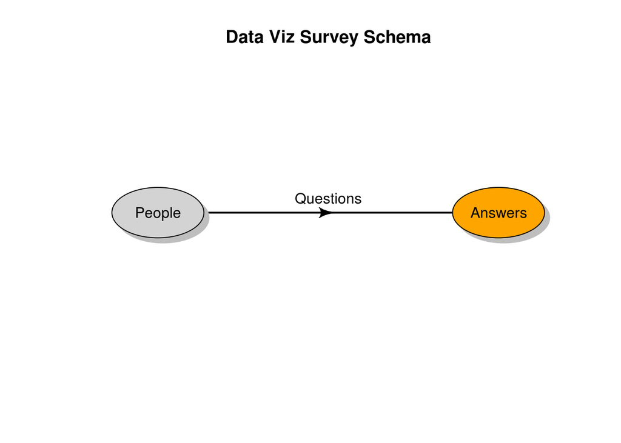

The two questions I want to answer by exploring this graph is:

1. What can we learn from the people who spend less than 5% of their time on data visualization, but claim that data visualization is a primary focus of their work? (Inspired by Shirley Wu’s closing comments in [655 Frustrations Doing Data Visualization](https://medium.com/visualizing-the-field/655-frustrations-doing-data-visualization-e1087c8176fc))
2. Who are people similar to me in the data viz community?

# Setup

## Packages

The packages we will need are **Tidyverse**, **stringr**, and **igraph**. I added the igraph helper functions from my last post to my package tinkR.

```r
packages <- c('tidyverse', 'stringr', 'igraph', 'tinkR')
sapply(packages, library, character.only = T)
```

## Data

The original data can be found in [Elijah Meeks github repository](https://github.com/emeeks/data_visualization_survey/tree/master/data). However, because we will work with a different version of the same dataset. I took the liberty and “graph-it-ized” (or “net-worked”, or “node-and-edgitized”) the csv so we can explore the survey results as we would a graph database. You can find the “graph-ee-teed” dataset [in my github repository](https://github.com/beemyfriend/beemyfriend.github.io/blob/master/Data/data_vis_survey.graphml)

```r
g <- read_graph("Data/data_vis_survey.graphml", 'graphml')
```

# Test Example

Before we dive into the graph, we should try out a test case to see if we understand the traversal logic.. While I did not take the survey, I do have answers for the questions on the survey. One of the questions on the survey is “What technologies do you use to visualize data?”. The tech I use are:

- D3
- Other Javascript
- Other R
- Inkscape
- ggplot
- Javascript
- JavaScript
- R Shiny
- R

I want to know:

1. How many people use each of those technologies?
2. Who are the individuals using most of these technologies? (Who has a similar stack as me?)

```r
#I want to know who gave the same answers as I did for a question
same_answers <- g %>%
  #find all edges
  E() %>%
  #filter edges that represent the question i'm interested in
  .[type == 'What technologies do you use to visualize data?'] %>%
  #create a subgraph from those edges
  reverse_subgraph_edges(g) %>%
  #save the subgraph for future reference
  save_as('question_net') %>%
  #find all edges of the subgraph
  E() %>%
  #filter edges that point towards my answers
  .[V(question_net) %->% V(question_net)[names(V(question_net)) %in% c("D3",
                                                                       "Other Javascript",
                                                                       "Other R",
                                                                       "Inkscape",
                                                                       "ggplot",
                                                                       'Javascript',
                                                                       "JavaScript",
                                                                       "R Shiny",
                                                                       "R")]] %>%
  #produce a graph of people who gave the same answers as me
  reverse_subgraph_edges(question_net)
```

Let’s see which one of my answers is the most common within the data visualization community.

```r
same_answers %>%
  #find the number of 'in' edges each node has
  #only answers in this graph have 'in' edges
  degree(mode = 'in') %>%
  #because people don't have 'in' edges they get a degree of 0
  .[. > 0] %>%
  #let's sort the results for cleanliness
  sort(T)
```

```
##               D3           ggplot          Other R Other Javascript
##              535              350              251              241
##         Inkscape       JavaScript       Javascript          R Shiny
##                7                1                1                1
##                R
##                1
```

Just as a reference, let’s take a look at the ten most popular technologies:

```r
#we created question_net when we created same_answers
#created has all the unfiltered
#'What technologies do you use to visualize data?' edges
question_net %>%
  degree(mode = 'in') %>%
  .[.>0] %>%
  sort(T) %>%
  head(10)
```

```
##            Excel               D3          Tableau           ggplot
##              574              535              356              350
##          Other R Other Javascript      Illustrator     Other Python
##              251              241              236              185
##          Leaflet           Pandas
##              182              157
```

Now, let’s see if anyone uses all or most of these technologies:

```r
same_answers %>%
  #find the number of 'out' edges each node has
  #only people in this graph have 'out' edges
  degree(mode = 'out') %>%
  .[.>0] %>%
  sort(T) %>%
  head()
```

```
## id: 128   id: 4  id: 43  id: 51  id: 65  id: 70
##       5       4       4       4       4       4
```

It seems that person **id: 128** has a similar stack as me. Let’s confirm this:

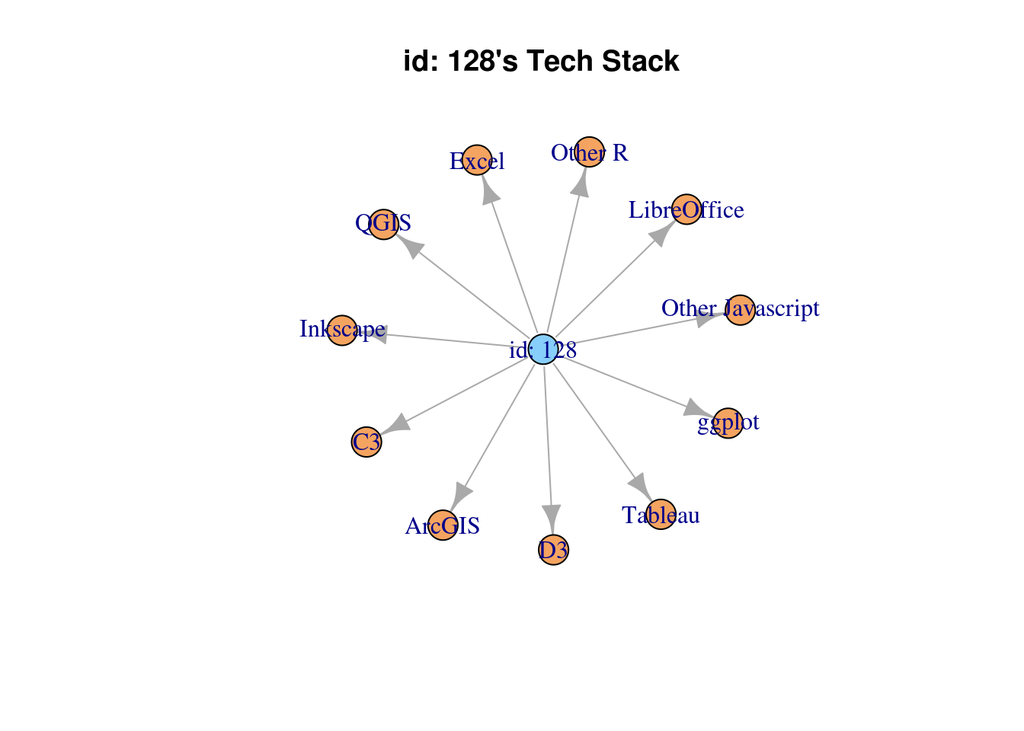

```r
question_net %>%
  E() %>%
  .[V(question_net)[names(V(question_net)) == 'id: 128'] %->% V(question_net)] %>%
  reverse_subgraph_edges(question_net) %>%
  plot()
title("id: 128's Tech Stack")
```

The person who is most similar to me seems to use **GIS** software and **C3**. Maybe I should look into developing those skills as well.

I’m also curious, what does this person do for work?

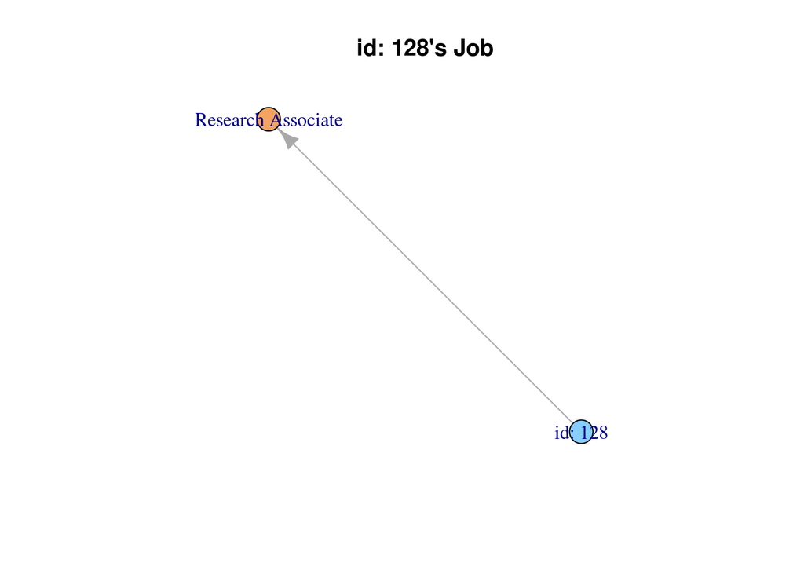

```r
#start with unfiltered net
g %>%
  E() %>%
  .[V(g)[names(V(g)) == 'id: 128'] %->% V(g)] %>%
  .[type == "What is your official job title?"] %>%
  reverse_subgraph_edges(g) %>%
  plot()
title("id: 128's Job")
```

Looking forward, we can identify a few patterns that we will need to use over and over again. Whenever we see a pattern with our code, we should wrap that pattern into a function to save us time typing and to prevent typos…let’s try to keep our code DRY.

```r
#Creates a subgraph of people who answered a question a certain way
getSameAnswers <- function(graph, question, answerVect){
  graph %>%
    E() %>%
    .[type == question] %>%
    reverse_subgraph_edges(graph) %>%
    save_as('question_net') %>%
    E() %>%
    .[V(question_net) %->% V(question_net)[names(V(question_net)) %in% answerVect]] %>%
    reverse_subgraph_edges(question_net)
}

#Get all the answers to a particular question
whatTheySaid <- function(g, question){
  g %>%
    E() %>%
    .[type == question] %>%
    reverse_subgraph_edges(g) %>%
    degree(mode = 'in') %>%
    .[.> 0] %>%
    sort(T)
}
```

# Shirley’s question

```
I just want to know, those that replied <5% time spent on visualization, but also answered that it was their primary focus…how does that even 🤔?
```

How can we try to make sense of people who spend less than 5% of their time on visualization but claiim that it is their primary focus? We have a lot of information at our disposal, but not all of it is useful in answering this question. I propose that we try to find out the following information:

1. What is their job? (maybe their job description can give us hints)
2. How long have they been in data viz? (Maybe they have seniority roles and have different responsibiilities)
3. How much time do they spend on other tasks? (Data prep, while not necessarily data viz, is a fundamental task)

We can answer these questions after we identify the people of interest:

```r
#identify those who spend less than 5% of their time on dataviz
lt5_dv <- getSameAnswers(g,
               "Percent of your day focused on creating/implementing/productizing data visualizations?",
               as.character(0:5) ) %>%
  V() %>%
  .[type == 'person'] %>%
  names()

#identify those whose primary focus is data viz
pfocus <- getSameAnswers(g,
                         "What focus is data visualization in your work?",
                         "Data visualization is the focus of my job") %>%
  V() %>%
  .[type == 'person'] %>%
  names()

# create a network of people that identify
# data viz as their primary focus
# AND spend les than 5% of their tie doing daa viz
dataViz_atrophy <- lt5_dv %>%
  .[. %in% pfocus] %>%
  reverse_ego(g) %>%
  unlist %>%
  names() %>%
  unique %>%
  reverse_induced_subgraph(g)
```

Let’s filter the network we created to include only questions that we think will help us understand the people of interest better.

```r
questionsOfInterest <- c(
  "What is your official job title?",
  "How many years have you been doing data visualization?",
  "Percent of your day focused on data engineering?",
  "Percent of your day focused on data science?",
  "Percent of your day focused on design?",
  "Percent of your day focused on data prep work?"
)

dataViz_atrophy_answers <- questionsOfInterest %>%
  lapply(function(x){
    q = x
    a = whatTheySaid(dataViz_atrophy, x)
    list(question = q, answer = a)
  })

names(dataViz_atrophy_answers) <- sapply(dataViz_atrophy_answers, function(x){x$question})

dataViz_atrophy_answers <- lapply(dataViz_atrophy_answers, function(x){
  x$answer
})

dataViz_atrophy_answers
```

```
## $`What is your official job title?`
##                            NA                    Consultant
##                             1                             1
##                     Professor Data Visualisation Specialist
##                             1                             1
##
## $`How many years have you been doing data visualization?`
## 10  1  7
##  2  1  1
##
## $`Percent of your day focused on data engineering?`
## 10 NA  0
##  2  1  1
##
## $`Percent of your day focused on data science?`
##  0  5 NA
##  2  1  1
##
## $`Percent of your day focused on design?`
## 10  5 NA 90
##  1  1  1  1
##
## $`Percent of your day focused on data prep work?`
## 10  5 NA  0
##  1  1  1  1
```

We have both a Professor and a consultant in this group. They probably spend most of their time in the classroom or in meetings. All but one person in this group have at least 7 years of experience so they could potentially have enough seniority to guide others in data visualization and work on more top-level things rather than the actual craft of data visualization. One person actually spends most of his/her time on design, which brings up a good question – is data engineering and design not part of the process of “creating/implementing/productizing data visualizations”? Is data visualization not data science?

You may have noticed that we are looking at summary statistics of these answers. This is necessary once we start looking at answers provided by larger groups of people. Unfortunatley, whenever we use summary statistics, we lose a lot of important information. For instances, the above summary does not actually let us know who said what. Just for fun, and because the network is small, let’s create an edge list for each individual of interest:

```r
dataViz_atrophy %>%
  V() %>%
  .[type == 'person'] %>%
  reverse_ego(dataViz_atrophy) %>%
  lapply(function(x){
    x %>%
      names() %>%
      reverse_induced_subgraph(dataViz_atrophy) %>%
      save_as('individualOfInterest') %>%
      E() %>%
      .[type %in% questionsOfInterest] %>%
      save_as('questionEdge') %>%
      reverse_subgraph_edges(individualOfInterest) %>%
      ends(E(.)) %>%
      as.tibble() %>%
      rename(person = V1,
             answer = V2) %>%
      mutate(question = questionEdge$type) %>%
      select(person, question, answer)  %>%
      arrange(question) %>%
      knitr::kable()
  })
```

```
## [[1]]
##
##
## person    question                                                 answer
## --------  -------------------------------------------------------  -----------
## id: 310   How many years have you been doing data visualization?   1
## id: 310   Percent of your day focused on data engineering?         NA
## id: 310   Percent of your day focused on data prep work?           NA
## id: 310   Percent of your day focused on data science?             NA
## id: 310   Percent of your day focused on design?                   NA
## id: 310   What is your official job title?                         Consultant
##
## [[2]]
##
##
## person    question                                                 answer
## --------  -------------------------------------------------------  ------------------------------
## id: 323   How many years have you been doing data visualization?   10
## id: 323   Percent of your day focused on data engineering?         0
## id: 323   Percent of your day focused on data prep work?           5
## id: 323   Percent of your day focused on data science?             0
## id: 323   Percent of your day focused on design?                   90
## id: 323   What is your official job title?                         Data Visualisation Specialist
##
## [[3]]
##
##
## person    question                                                 answer
## --------  -------------------------------------------------------  ----------
## id: 496   How many years have you been doing data visualization?   10
## id: 496   Percent of your day focused on data engineering?         10
## id: 496   Percent of your day focused on data prep work?           10
## id: 496   Percent of your day focused on data science?             5
## id: 496   Percent of your day focused on design?                   10
## id: 496   What is your official job title?                         Professor
##
## [[4]]
##
##
## person    question                                                 answer
## --------  -------------------------------------------------------  -------
## id: 797   How many years have you been doing data visualization?   7
## id: 797   Percent of your day focused on data engineering?         10
## id: 797   Percent of your day focused on data prep work?           0
## id: 797   Percent of your day focused on data science?             0
## id: 797   Percent of your day focused on design?                   5
## id: 797   What is your official job title?                         NA
```

# Finding myself within the community

Traversing a graph lends itself to being a pretty good recommendation system. To test this out, we will try to find people like me within the community. I did not take the survey myself. Below is a tibble with some of my answers to the survey questions. We will use this tibble to find people who answered the same quesions like I did.

```r
my_survey_responses <- tibble(
  questions = c(
    "What's your employment status",
    "How many years have you been doing data visualization?",
    "Is your total compensation in-line with Software Engineers and UX/UI/Designer roles at your level?",
    "Where do you live?",
    "How did you learn to create data visualization?",
    "Is this your first job doing data visualization?",
    "What is your educational background?",
    "What’s your ethnicity?",
    "What focus is data visualization in your work?",
    "Do you want to spend more time or less time visualizing data in the future?",
    "Age",
    "The organization you work for is in which of the following?",
    "Gender",
    "What technologies do you use to visualize data?",
    "Did you set out to work in data visualization or did you fall into it?"
  ),
  answers = list(
    c("Full-time"),
    c("1", "2"),
    c("Data Visualization Role has Lower compensation"),
    c("USA or Canada"),
    c("Mostly Self-Taught"),
    c("Yes"),
    c("Bachelors"),
    c("white", "hispanic"),
    c("Data visualization is the focus of my job"),
    c("Much more"),
    c("26 - 35"),
    c("Mixed"),
    c('male'),
    c("D3", "Other Javascript", "Other R", "Inkscape", "ggplot", "JavaScript", "R Shiny", "R"),
    c('Intended to work in data visualization')
  )
)
```

## Filtering the network for those who are like me

Let’s create networks of people who answered questions like I did. The below code creates a list of subgraphs that have only one question represented and only includes people who answered the question like I did.

```r
#create subnetworks of people who answered questions as I did
same_answers <- lapply(seq_along(my_survey_responses$questions), function(i){
  getSameAnswers(g,
                 my_survey_responses$questions[i],
                 my_survey_responses$answers[[i]])
})
```

We want to create a single graph by combining each of the subgraphs together. Combining graphs together is a little tricky and I haven’t figured out a more efficient way to combine graphs together. What we will do is create multiple tibbles representing edge lists, bind them together, and then make a completely new graph using `graph_from_data_frame()`

```r
edges <- lapply(same_answers, function(x){
  el <- x %>%
    #creates  matrix with source in first column and target in second column
    ends(E(.)) %>%
    as.tibble() %>%
    mutate(type = x %>% E() %>% .$type %>% .[1]) %>%
    rename(source = V1,
           target = V2)})%>%
  bind_rows()

networkLikeMe <- graph_from_data_frame(edges)
```

Let’s take a look at the ten people who answered these questions like me. The higher the degree, the more question they answered like me.

```r
networkLikeMe %>%
  degree(mode = 'out') %>%
  .[.>0] %>%
  sort(T) %>%
  head(10)
```

```
##  id: 43 id: 170 id: 295 id: 705 id: 775  id: 27 id: 209 id: 240 id: 254
##      13      13      13      13      13      12      12      12      12
## id: 307
##      12
```

I’ve only answered 15 questions, so people who have at least 12 similar connections to me seems like a decent cut-off point for deciding whether or not someone is similar to me. Let’s create a network of people who have at least 12 similar connections to me:

```r
networkLikeMe_full <- networkLikeMe %>%
  V() %>%
  .[degree(networkLikeMe, mode = 'out') >= 12] %>%
  names() %>%
  save_as('peopleLikeMe') %>%
  smooth_transition(networkLikeMe) %>%
  E() %>%
  .[peopleLikeMe %->% V(networkLikeMe)] %>%
  reverse_subgraph_edges(networkLikeMe)
```

Let’s identify the people who are similar to me.

```r
peopleLikeMe
```

```
##  [1] "id: 27"  "id: 43"  "id: 170" "id: 209" "id: 240" "id: 254" "id: 295"
##  [8] "id: 307" "id: 361" "id: 403" "id: 454" "id: 455" "id: 497" "id: 705"
## [15] "id: 775" "id: 803" "id: 960"
```

There are 17 people who are similar to me out of 979. Let’s explore these people:

```r
peopleLikeMe_full <- peopleLikeMe %>%
  reverse_ego(g, 1) %>%
  unlist %>%
  names() %>%
  unique %>%
  reverse_induced_subgraph(g)
```

My current job title is “Data Visualization Programmer”, let’s check out the jobs of people like me:

```r
peopleLikeMe_full %>%
  E() %>%
  .[type == "What is your official job title?" ] %>%
  reverse_subgraph_edges(peopleLikeMe_full) %>%
  degree(mode = 'in') %>%
  .[. > 0] %>%
  sort(T)
```

```
##                                                Graphics Editor
##                                                              2
##                                    Data Visualization Engineer
##                                                              2
##                                                Data Journalist
##                                                              1
## Research Associate for Information Synthesis and Dissemination
##                                                              1
##                                                   Data Analyst
##                                                              1
##                                     Data Visualization Analyst
##                                                              1
##                                                 Data Scientist
##                                                              1
##                                             Research Associate
##                                                              1
##                                                     Researcher
##                                                              1
##                                           Senior Urban Planner
##                                                              1
##            Director Office of Data Research and Accountability
##                                                              1
##                                               Business Analyst
##                                                              1
##                                     Faculty Research Associate
##                                                              1
##                                     Data Visualisation Manager
##                                                              1
##                                                   Statistician
##                                                              1
```

“Data Visualization Engineer” seem synonymous to “Data Visualization Engineer” so it makes sense as one of the top jobs listed for people like me. “Graphics Editor” and “Data Journalist” are two positions that I would love to have. So it’s neat that people with those jobs can be found in a list of people like me. Just for comparison, let’s check out what are the top ten jobs of the community:

```r
g %>%
  E() %>%
  .[type == "What is your official job title?"] %>%
  reverse_subgraph_edges(g) %>%
  degree(mode = 'in') %>%
  sort(T) %>%
  head(10)
```

```
##                       NA           Data Scientist               Consultant
##                       85                       49                       20
##        Software Engineer             Data Analyst               Researcher
##                       17                       16                       13
##                  Analyst Senior Software Engineer       Software Developer
##                        9                        9                        9
##               Freelancer
##                        8
```

Neither “Data Visualization Engineer”, “Graphics Editor”, nor “Data Journalist” show up as a top ten job for the community. This implies that the people listed in *peopleLikeMe* are actually like me and not just a typical person in the data viz community. Cool, it seems like graph traversal is doing a good job of identifying people like me. Let’s create the building blocks to see how people like me answered questions:

```r
questions <- g %>%
  E() %>%
  .$type %>%
  unique

similarAnswers <- lapply(questions, function(x){
  q <- x
  a <- whatTheySaid(peopleLikeMe_full, x)
  list(
    question = q,
    answers = a
  )})

names(similarAnswers) <- sapply(similarAnswers, function(x){x$question})

similarAnswers <- lapply(similarAnswers, function(x){x$answers})
```

Let’s explore how people like me answered some questions:

```r
similarAnswers$`Who do you look to as a thought leader in data visualization?`
```

```
##             NA   Mike Bostock Tamara Munzner  Alberto Cairo      Andy Kirk
##              5              5              3              2              2
## Hadley Wickham   Jeffrey Heer        Tableau     Nathan Yau   Hans Rosling
##              2              2              1              1              1
##  Nadieh Bremer     Amanda Cox   Andy Kriebel   Elijah Meeks Santiago Ortiz
##              1              1              1              1              1
##     Chris Viau
##              1
```

```r
similarAnswers$`Who do you make data visualizations for?`
```

```
##              Analysts        General Public            Executives
##                    12                    10                     9
##            Scientists             Engineers      Project Managers
##                     5                     4                     4
##      Product Managers Medical Professionals               Clients
##                     2                     2                     1
```

```r
similarAnswers$`Which of these charts have you used in production in the last 6 months:`
```

```
##      Line Chart       Bar Chart  Choropleth Map         Treemap
##              16              15              12               6
## Network Diagram    Flow Diagram       Pie Chart    Infographics
##               6               5               4               3
##      Raster Map      Dendrogram    venn diagram     Scatterplot
##               2               1               1               1
##     slope chart       cartogram        Heat Map
##               1               1               1
```

```r
similarAnswers$`What technologies do you use to visualize data?`
```

```
##                                D3                            ggplot
##                                15                                14
##                             Excel                  Other Javascript
##                                10                                10
##                           Other R                           Leaflet
##                                10                                 8
##                           Tableau                      Other Python
##                                 6                                 5
##                       Illustrator                        Highcharts
##                                 4                                 4
##                            Pandas                              QGIS
##                                 4                                 4
##                            Plotly                            Mapbox
##                                 3                                 3
##                             React                        Processing
##                                 3                                 3
##                              Vega                             WebGL
##                                 2                                 2
##                              Java                          Power BI
##                                 2                                 1
##                          Other BI                            ArcGIS
##                                 1                                 1
##                     After Effects                           Angular
##                                 1                                 1
##                         Other MVC Other Network Visualization Suite
##                                 1                                 1
##                            Sketch                             Stata
##                                 1                                 1
##                       google docs                          Recharts
##                                 1                                 1
##                          Chart.JS
##                                 1
```

# Conclusion

The topic of community was spoken about a lot last year. Julia Silge explored the topic [useR!2017](https://juliasilge.com/blog/navigating-packages/). Eric Socolofsky and Elijah Meeks developed a Medium page specifically focusing on [Visualizing, The Field](https://medium.com/visualizing-the-field). Exploring community surveys is important for identifying the health of a community, but also exploring the indiiduals that create those communities.

# Ending Thoughts

Before I moved back to the states I lived on a farm in South America. I lived with family, and while I wasn’t alone, I definitely felt lonely. I had a lot of free time and I eventually decided to learn how to code. My spanish was pretty bad and I didn’t know anyone nearby who could teach me how to code, so I had to learn everything online. And while I am technically “Mostly Self-Taught” I would never be able to do what I can do now if it weren’t for the wonderful online **R** and **D3** communities. Very awesome people within these communities took their time to write tutorials so people like me could learn. Some were even kind enough to look at my code and give me advice directly. The [**D3 slack channel**](https://d3-slackin.herokuapp.com/) in particular was a place that provided me with both a place to learn as well as a social outlet. I care very deeply about these communities and being able to find people similar to me within them makes me really happy - it implies that I actually do belong within their ranks.

# Appendix

Just in case you want to learn more about people like me, below is their answers to all the questions.

```r
personProfile <- function(g){
  g %>%
    V() %>%
    .[type == 'person'] %>%
    reverse_ego(g) %>%
    lapply(function(x){
      x %>%
        names() %>%
        reverse_induced_subgraph(g) %>%
        save_as('individualOfInterest') %>%
        E() %>%
        .[type %in% questions] %>%
        save_as('questionEdge') %>%
        reverse_subgraph_edges(individualOfInterest) %>%
        ends(E(.)) %>%
        as.tibble() %>%
        rename(person = V1,
               answer = V2) %>%
        mutate(question = questionEdge$type) %>%
        select(person, question, answer)  %>%
        arrange(question) %>%
        knitr::kable()
  })
}

personProfile(peopleLikeMe_full)
```

[[1]]

| person | question | answer |
| --- | --- | --- |
| id: 27 | Age | 26 - 35 |
| id: 27 | Are data visualization specialists represented in the leadership of your organization? | No |
| id: 27 | Are you able to choose your own tools or are the choices made for you? | I’m able to choose my own tools. |
| id: 27 | Data visualization roles at your organization are found in what part of the organization? | Research |
| id: 27 | Data visualization roles at your organization are found in what part of the organization? | Design |
| id: 27 | Did you set out to work in data visualization or did you fall into it? | Ended up doing data visualization as a requirement of the job |
| id: 27 | Do you want to spend more time or less time visualizing data in the future? | More |
| id: 27 | For your current role or the majority of your projects: were you hired to do data visualization only or is data visualization a part of your job/project description? | Data visualization is only part of my job |
| id: 27 | Gender | male |
| id: 27 | How did you learn to create data visualization? | Mostly Self-Taught |
| id: 27 | How do you present your data visualizations? | Embedded in a tool |
| id: 27 | How do you present your data visualizations? | Presentations |
| id: 27 | How do you present your data visualizations? | Static Web Page |
| id: 27 | How do you present your data visualizations? | Documents |
| id: 27 | How do you present your data visualizations? | Email |
| id: 27 | How do you present your data visualizations? | Scrollytelling |
| id: 27 | How is your organization using data visualization? | Analysis |
| id: 27 | How is your organization using data visualization? | Summary/Overview |
| id: 27 | How is your organization using data visualization? | Communication |
| id: 27 | How is your organization using data visualization? | Marketing |
| id: 27 | How many years have you been doing data visualization? | 4 |
| id: 27 | How often do they consume your data visualizations? | Weekly |
| id: 27 | How would you describe the relationship? | Collaborative |
| id: 27 | If you could change one thing about your data visualization work what would it be? | NA |
| id: 27 | If you could change one thing about your job what would it be? | More on-the-job- hands on trainings on new tools- so I can learn by doing. |
| id: 27 | Is there a separate group that does data visualizations or are you embedded in another group? (data science UX UI web data engineering IT etc) | Embedded in another team |
| id: 27 | Is this your first job doing data visualization? | Yes |
| id: 27 | Is your total compensation in-line with Software Engineers and UX/UI/Designer roles at your level? | Data Visualization Role has Lower compensation |
| id: 27 | Percent of your day focused on creating/implementing/productizing data visualizations? | 50 |
| id: 27 | Percent of your day focused on data engineering? | 0 |
| id: 27 | Percent of your day focused on data prep work? | 15 |
| id: 27 | Percent of your day focused on data science? | 5 |
| id: 27 | Percent of your day focused on design? | 30 |
| id: 27 | The organization you work for is in which of the following? | Not-for-profit |
| id: 27 | Timestamp | 2/27/2017 12:56:04 |
| id: 27 | What community support / discussions / advice would you want to see from data visualization thought leaders? | More in-person workshops/training/meetups for beginners where people of all skill levels could come to talk through ideas and work on projects with help from peers or mentors. |
| id: 27 | What do they use your data visualizations for? | Analysis |
| id: 27 | What do they use your data visualizations for? | Research |
| id: 27 | What do they use your data visualizations for? | Summarization |
| id: 27 | What do they use your data visualizations for? | Learning |
| id: 27 | What do you think other people in your organization just don’t get about the data visualization work that you do? | Two things: 1) the amount of time it takes to produce data viz. 2) the breadth of data-viz options available to them. |
| id: 27 | What focus is data visualization in your work? | Data visualization is an important secondary part of my job but not the focus |
| id: 27 | What is your biggest frustration with doing data visualization in your job? | NA |
| id: 27 | What is your biggest frustration with your job? | Keeping up with new tools and learning how to use them (steep learning curves- lack of on-the-job training). |
| id: 27 | What is your educational background? | Bachelors |
| id: 27 | What is your official job title? | Research Associate for Information Synthesis and Dissemination |
| id: 27 | What knowledge level do they have of the data you are visualizing for them? | Moderate |
| id: 27 | What knowledge level do they have of the data you are visualizing for them? | Expert |
| id: 27 | What level of data visualizations are used at your organization? | Business Intelligence Tools |
| id: 27 | What level of data visualizations are used at your organization? | General charting libraries |
| id: 27 | What level of data visualizations are used at your organization? | ggplot2/Pandas Charts |
| id: 27 | What one change would make your job better? | More trainings on new tools- especially R/ggplot- D3- Ruby on Rails- and front end web development–javascript in particular. |
| id: 27 | What’s your employment status | Full-time |
| id: 27 | What’s your ethnicity? | white |
| id: 27 | What technologies do you use to visualize data? | Excel |
| id: 27 | What technologies do you use to visualize data? | Tableau |
| id: 27 | What technologies do you use to visualize data? | Other Javascript |
| id: 27 | What technologies do you use to visualize data? | Illustrator |
| id: 27 | What technologies do you use to visualize data? | Highcharts |
| id: 27 | What technologies do you use to visualize data? | ggplot |
| id: 27 | What technologies do you use to visualize data? | Other R |
| id: 27 | What technologies do you use to visualize data? | After Effects |
| id: 27 | Where do you live? | USA or Canada |
| id: 27 | Which of these charts have you used in production in the last 6 months: | Line Chart |
| id: 27 | Which of these charts have you used in production in the last 6 months: | Bar Chart |
| id: 27 | Which of these charts have you used in production in the last 6 months: | Infographics |
| id: 27 | Which of these charts have you used in production in the last 6 months: | Pie Chart |
| id: 27 | Which of these charts have you used in production in the last 6 months: | Treemap |
| id: 27 | Which of these charts have you used in production in the last 6 months: | Flow Diagram |
| id: 27 | Which of these charts have you used in production in the last 6 months: | venn diagram |
| id: 27 | Who do you look to as a thought leader in data visualization? | Alberto Cairo |
| id: 27 | Who do you look to as a thought leader in data visualization? | Hans Rosling |
| id: 27 | Who do you make data visualizations for? | Analysts |
| id: 27 | Who do you make data visualizations for? | Executives |
| id: 27 | Who do you make data visualizations for? | General Public |

[[2]]

| person | question | answer |
| --- | --- | --- |
| id: 43 | Age | 26 - 35 |
| id: 43 | Are data visualization specialists represented in the leadership of your organization? | Yes |
| id: 43 | Are you able to choose your own tools or are the choices made for you? | I’m able to choose my own tools. |
| id: 43 | Data visualization roles at your organization are found in what part of the organization? | Design |
| id: 43 | Data visualization roles at your organization are found in what part of the organization? | Engineering |
| id: 43 | Did you set out to work in data visualization or did you fall into it? | Intended to work in data visualization |
| id: 43 | Do you want to spend more time or less time visualizing data in the future? | More |
| id: 43 | For your current role or the majority of your projects: were you hired to do data visualization only or is data visualization a part of your job/project description? | Hired to do data visualization |
| id: 43 | Gender | male |
| id: 43 | How did you learn to create data visualization? | Mostly Self-Taught |
| id: 43 | How do you present your data visualizations? | Dashboard |
| id: 43 | How do you present your data visualizations? | Presentations |
| id: 43 | How do you present your data visualizations? | Static Web Page |
| id: 43 | How do you present your data visualizations? | Scrollytelling |
| id: 43 | How is your organization using data visualization? | Analysis |
| id: 43 | How is your organization using data visualization? | Communication |
| id: 43 | How is your organization using data visualization? | Marketing |
| id: 43 | How is your organization using data visualization? | Exploration |
| id: 43 | How many years have you been doing data visualization? | 6 |
| id: 43 | How often do they consume your data visualizations? | Weekly |
| id: 43 | How would you describe the relationship? | Consultative |
| id: 43 | If you could change one thing about your data visualization work what would it be? | make it flashier |
| id: 43 | If you could change one thing about your job what would it be? | add more data science and analysis to the process. |
| id: 43 | Is there a separate group that does data visualizations or are you embedded in another group? (data science UX UI web data engineering IT etc) | Separate data visualization team |
| id: 43 | Is this your first job doing data visualization? | No |
| id: 43 | Is your total compensation in-line with Software Engineers and UX/UI/Designer roles at your level? | Data Visualization Role has Lower compensation |
| id: 43 | Percent of your day focused on creating/implementing/productizing data visualizations? | 40 |
| id: 43 | Percent of your day focused on data engineering? | 20 |
| id: 43 | Percent of your day focused on data prep work? | 20 |
| id: 43 | Percent of your day focused on data science? | 10 |
| id: 43 | Percent of your day focused on design? | 10 |
| id: 43 | The organization you work for is in which of the following? | Private sector |
| id: 43 | Timestamp | 3/3/2017 9:06:25 |
| id: 43 | What community support / discussions / advice would you want to see from data visualization thought leaders? | move forward data vis literacy. |
| id: 43 | What do they use your data visualizations for? | Analysis |
| id: 43 | What do they use your data visualizations for? | Research |
| id: 43 | What do they use your data visualizations for? | Summarization |
| id: 43 | What do they use your data visualizations for? | Learning |
| id: 43 | What do you think other people in your organization just don’t get about the data visualization work that you do? | the power of answering questions with the data. |
| id: 43 | What focus is data visualization in your work? | Data visualization is the focus of my job |
| id: 43 | What is your biggest frustration with doing data visualization in your job? | getting more into webgl |
| id: 43 | What is your biggest frustration with your job? | communication with client and co-workers is hard - human interactions are still the biggest challenge in all industries I’ve encountered. |
| id: 43 | What is your educational background? | Masters |
| id: 43 | What is your official job title? | Data Visualization Engineer |
| id: 43 | What knowledge level do they have of the data you are visualizing for them? | Moderate |
| id: 43 | What knowledge level do they have of the data you are visualizing for them? | Expert |
| id: 43 | What level of data visualizations are used at your organization? | ggplot2/Pandas Charts |
| id: 43 | What level of data visualizations are used at your organization? | Completely custom |
| id: 43 | What one change would make your job better? | have time to inject more prediction and analysis into the process. |
| id: 43 | What’s your employment status | Full-time |
| id: 43 | What’s your ethnicity? | white |
| id: 43 | What technologies do you use to visualize data? | D3 |
| id: 43 | What technologies do you use to visualize data? | Other Javascript |
| id: 43 | What technologies do you use to visualize data? | Leaflet |
| id: 43 | What technologies do you use to visualize data? | WebGL |
| id: 43 | What technologies do you use to visualize data? | ggplot |
| id: 43 | What technologies do you use to visualize data? | Other R |
| id: 43 | What technologies do you use to visualize data? | Mapbox |
| id: 43 | What technologies do you use to visualize data? | Other Python |
| id: 43 | What technologies do you use to visualize data? | Pandas |
| id: 43 | What technologies do you use to visualize data? | React |
| id: 43 | What technologies do you use to visualize data? | QGIS |
| id: 43 | What technologies do you use to visualize data? | Other Network Visualization Suite |
| id: 43 | What technologies do you use to visualize data? | Sketch |
| id: 43 | Where do you live? | USA or Canada |
| id: 43 | Which of these charts have you used in production in the last 6 months: | Line Chart |
| id: 43 | Which of these charts have you used in production in the last 6 months: | Bar Chart |
| id: 43 | Which of these charts have you used in production in the last 6 months: | Treemap |
| id: 43 | Which of these charts have you used in production in the last 6 months: | Network Diagram |
| id: 43 | Which of these charts have you used in production in the last 6 months: | Choropleth Map |
| id: 43 | Who do you look to as a thought leader in data visualization? | Amanda Cox |
| id: 43 | Who do you make data visualizations for? | Analysts |
| id: 43 | Who do you make data visualizations for? | Engineers |
| id: 43 | Who do you make data visualizations for? | Executives |
| id: 43 | Who do you make data visualizations for? | General Public |
| id: 43 | Who do you make data visualizations for? | Medical Professionals |

[[3]]

| person | question | answer |
| --- | --- | --- |
| id: 170 | Age | 26 - 35 |
| id: 170 | Are data visualization specialists represented in the leadership of your organization? | Yes |
| id: 170 | Are you able to choose your own tools or are the choices made for you? | I’m able to choose my own tools. |
| id: 170 | Data visualization roles at your organization are found in what part of the organization? | Design |
| id: 170 | Did you set out to work in data visualization or did you fall into it? | Ended up doing data visualization as a requirement of the job |
| id: 170 | Do you want to spend more time or less time visualizing data in the future? | Much more |
| id: 170 | For your current role or the majority of your projects: were you hired to do data visualization only or is data visualization a part of your job/project description? | Data visualization is only part of my job |
| id: 170 | Gender | male |
| id: 170 | How did you learn to create data visualization? | Mostly Self-Taught |
| id: 170 | How do you present your data visualizations? | Dashboard |
| id: 170 | How do you present your data visualizations? | Presentations |
| id: 170 | How do you present your data visualizations? | Static Web Page |
| id: 170 | How do you present your data visualizations? | Documents |
| id: 170 | How do you present your data visualizations? | Email |
| id: 170 | How is your organization using data visualization? | Analysis |
| id: 170 | How is your organization using data visualization? | Summary/Overview |
| id: 170 | How is your organization using data visualization? | Communication |
| id: 170 | How is your organization using data visualization? | Marketing |
| id: 170 | How is your organization using data visualization? | Exploration |
| id: 170 | How many years have you been doing data visualization? | 5 |
| id: 170 | How often do they consume your data visualizations? | Daily |
| id: 170 | How would you describe the relationship? | Consultative |
| id: 170 | If you could change one thing about your data visualization work what would it be? | Design more interactive-first and less static materials designed to work on a web page or PDF |
| id: 170 | If you could change one thing about your job what would it be? | More focus on the most interesting g data and viz problems |
| id: 170 | Is there a separate group that does data visualizations or are you embedded in another group? (data science UX UI web data engineering IT etc) | Embedded in another team |
| id: 170 | Is this your first job doing data visualization? | Yes |
| id: 170 | Is your total compensation in-line with Software Engineers and UX/UI/Designer roles at your level? | Don’t Know/Prefer Not to Say |
| id: 170 | Percent of your day focused on creating/implementing/productizing data visualizations? | 5 |
| id: 170 | Percent of your day focused on data engineering? | 15 |
| id: 170 | Percent of your day focused on data prep work? | 10 |
| id: 170 | Percent of your day focused on data science? | 15 |
| id: 170 | Percent of your day focused on design? | 15 |
| id: 170 | The organization you work for is in which of the following? | Private sector |
| id: 170 | Timestamp | 3/2/2017 23:29:10 |
| id: 170 | What community support / discussions / advice would you want to see from data visualization thought leaders? | NA |
| id: 170 | What do they use your data visualizations for? | Analysis |
| id: 170 | What do they use your data visualizations for? | Learning |
| id: 170 | What do they use your data visualizations for? | Political decision making |
| id: 170 | What do you think other people in your organization just don’t get about the data visualization work that you do? | The underlying logic and design philosophy |
| id: 170 | What focus is data visualization in your work? | Data visualization is an important secondary part of my job but not the focus |
| id: 170 | What is your biggest frustration with doing data visualization in your job? | Not having time to learn all the great tools that are out there. |
| id: 170 | What is your biggest frustration with your job? | Lack of audience knowledge (have to train them!) |
| id: 170 | What is your educational background? | Bachelors |
| id: 170 | What is your official job title? | Senior Urban Planner |
| id: 170 | What knowledge level do they have of the data you are visualizing for them? | Moderate |
| id: 170 | What knowledge level do they have of the data you are visualizing for them? | Intro |
| id: 170 | What level of data visualizations are used at your organization? | Business Intelligence Tools |
| id: 170 | What level of data visualizations are used at your organization? | General charting libraries |
| id: 170 | What level of data visualizations are used at your organization? | ggplot2/Pandas Charts |
| id: 170 | What level of data visualizations are used at your organization? | Completely custom |
| id: 170 | What level of data visualizations are used at your organization? | GIS |
| id: 170 | What one change would make your job better? | More focus on designing for the internet- less on antiquated print media |
| id: 170 | What’s your employment status | Full-time |
| id: 170 | What’s your ethnicity? | white |
| id: 170 | What technologies do you use to visualize data? | Excel |
| id: 170 | What technologies do you use to visualize data? | Tableau |
| id: 170 | What technologies do you use to visualize data? | D3 |
| id: 170 | What technologies do you use to visualize data? | Other Javascript |
| id: 170 | What technologies do you use to visualize data? | Illustrator |
| id: 170 | What technologies do you use to visualize data? | Leaflet |
| id: 170 | What technologies do you use to visualize data? | ggplot |
| id: 170 | What technologies do you use to visualize data? | Other R |
| id: 170 | What technologies do you use to visualize data? | Mapbox |
| id: 170 | What technologies do you use to visualize data? | QGIS |
| id: 170 | Where do you live? | USA or Canada |
| id: 170 | Which of these charts have you used in production in the last 6 months: | Line Chart |
| id: 170 | Which of these charts have you used in production in the last 6 months: | Bar Chart |
| id: 170 | Which of these charts have you used in production in the last 6 months: | Network Diagram |
| id: 170 | Which of these charts have you used in production in the last 6 months: | Choropleth Map |
| id: 170 | Which of these charts have you used in production in the last 6 months: | Raster Map |
| id: 170 | Who do you look to as a thought leader in data visualization? | Hadley Wickham |
| id: 170 | Who do you make data visualizations for? | Analysts |
| id: 170 | Who do you make data visualizations for? | Executives |
| id: 170 | Who do you make data visualizations for? | General Public |
| id: 170 | Who do you make data visualizations for? | Project Managers |

[[4]]

| person | question | answer |
| --- | --- | --- |
| id: 209 | Age | 26 - 35 |
| id: 209 | Are data visualization specialists represented in the leadership of your organization? | Yes |
| id: 209 | Are you able to choose your own tools or are the choices made for you? | I’m able to choose my own tools. |
| id: 209 | Data visualization roles at your organization are found in what part of the organization? | Research |
| id: 209 | Data visualization roles at your organization are found in what part of the organization? | C suite |
| id: 209 | Did you set out to work in data visualization or did you fall into it? | Ended up doing data visualization as a requirement of the job |
| id: 209 | Do you want to spend more time or less time visualizing data in the future? | Much more |
| id: 209 | For your current role or the majority of your projects: were you hired to do data visualization only or is data visualization a part of your job/project description? | Data visualization is only part of my job |
| id: 209 | Gender | male |
| id: 209 | How did you learn to create data visualization? | Mostly Self-Taught |
| id: 209 | How do you present your data visualizations? | Embedded in a tool |
| id: 209 | How do you present your data visualizations? | Dashboard |
| id: 209 | How do you present your data visualizations? | Presentations |
| id: 209 | How do you present your data visualizations? | Static Web Page |
| id: 209 | How do you present your data visualizations? | Documents |
| id: 209 | How do you present your data visualizations? | Scrollytelling |
| id: 209 | How is your organization using data visualization? | Summary/Overview |
| id: 209 | How is your organization using data visualization? | Communication |
| id: 209 | How many years have you been doing data visualization? | 7 |
| id: 209 | How often do they consume your data visualizations? | Yearly |
| id: 209 | How would you describe the relationship? | Subordinate |
| id: 209 | If you could change one thing about your data visualization work what would it be? | more acceptance of visualization decisions |
| id: 209 | If you could change one thing about your job what would it be? | Staffing |
| id: 209 | Is there a separate group that does data visualizations or are you embedded in another group? (data science UX UI web data engineering IT etc) | NA |
| id: 209 | Is this your first job doing data visualization? | No |
| id: 209 | Is your total compensation in-line with Software Engineers and UX/UI/Designer roles at your level? | Data Visualization Role has Lower compensation |
| id: 209 | Percent of your day focused on creating/implementing/productizing data visualizations? | 5 |
| id: 209 | Percent of your day focused on data engineering? | 5 |
| id: 209 | Percent of your day focused on data prep work? | 10 |
| id: 209 | Percent of your day focused on data science? | 10 |
| id: 209 | Percent of your day focused on design? | 5 |
| id: 209 | The organization you work for is in which of the following? | Public sector |
| id: 209 | Timestamp | 3/3/2017 3:51:23 |
| id: 209 | What community support / discussions / advice would you want to see from data visualization thought leaders? | Strategies for educating the audience about data visualization and why certain choices are made. |
| id: 209 | What do they use your data visualizations for? | Reporting requirements |
| id: 209 | What do you think other people in your organization just don’t get about the data visualization work that you do? | The time and effort required to create visualizations when working with large transactional systems that require extensive cleaning and preparation. |
| id: 209 | What focus is data visualization in your work? | Data visualization is an important secondary part of my job but not the focus |
| id: 209 | What is your biggest frustration with doing data visualization in your job? | Lack of trust that I am selecting the best and most appropriate method to visualize the data. |
| id: 209 | What is your biggest frustration with your job? | Too many meetings and difficulties hiring team members |
| id: 209 | What is your educational background? | PhD |
| id: 209 | What is your official job title? | Director Office of Data Research and Accountability |
| id: 209 | What knowledge level do they have of the data you are visualizing for them? | Intro |
| id: 209 | What level of data visualizations are used at your organization? | Modeling |
| id: 209 | What level of data visualizations are used at your organization? | Business Intelligence Tools |
| id: 209 | What level of data visualizations are used at your organization? | General charting libraries |
| id: 209 | What level of data visualizations are used at your organization? | ggplot2/Pandas Charts |
| id: 209 | What level of data visualizations are used at your organization? | Completely custom |
| id: 209 | What one change would make your job better? | Additional staff |
| id: 209 | What’s your employment status | Full-time |
| id: 209 | What’s your ethnicity? | white |
| id: 209 | What technologies do you use to visualize data? | Tableau |
| id: 209 | What technologies do you use to visualize data? | Plotly |
| id: 209 | What technologies do you use to visualize data? | D3 |
| id: 209 | What technologies do you use to visualize data? | Other Javascript |
| id: 209 | What technologies do you use to visualize data? | Vega |
| id: 209 | What technologies do you use to visualize data? | Leaflet |
| id: 209 | What technologies do you use to visualize data? | Highcharts |
| id: 209 | What technologies do you use to visualize data? | ggplot |
| id: 209 | What technologies do you use to visualize data? | Other R |
| id: 209 | What technologies do you use to visualize data? | Other Python |
| id: 209 | What technologies do you use to visualize data? | Other BI |
| id: 209 | What technologies do you use to visualize data? | Pandas |
| id: 209 | What technologies do you use to visualize data? | React |
| id: 209 | What technologies do you use to visualize data? | QGIS |
| id: 209 | What technologies do you use to visualize data? | Angular |
| id: 209 | What technologies do you use to visualize data? | Other MVC |
| id: 209 | What technologies do you use to visualize data? | Java |
| id: 209 | What technologies do you use to visualize data? | Stata |
| id: 209 | Where do you live? | USA or Canada |
| id: 209 | Which of these charts have you used in production in the last 6 months: | Line Chart |
| id: 209 | Who do you look to as a thought leader in data visualization? | Andy Kirk |
| id: 209 | Who do you look to as a thought leader in data visualization? | Mike Bostock |
| id: 209 | Who do you look to as a thought leader in data visualization? | Jeffrey Heer |
| id: 209 | Who do you make data visualizations for? | Analysts |
| id: 209 | Who do you make data visualizations for? | Executives |
| id: 209 | Who do you make data visualizations for? | General Public |
| id: 209 | Who do you make data visualizations for? | Product Managers |
| id: 209 | Who do you make data visualizations for? | Project Managers |

[[5]]

| person | question | answer |
| --- | --- | --- |
| id: 240 | Age | 26 - 35 |
| id: 240 | Are data visualization specialists represented in the leadership of your organization? | Yes |
| id: 240 | Are you able to choose your own tools or are the choices made for you? | I’m able to choose my own tools. |
| id: 240 | Data visualization roles at your organization are found in what part of the organization? | Research |
| id: 240 | Data visualization roles at your organization are found in what part of the organization? | Editorial |
| id: 240 | Did you set out to work in data visualization or did you fall into it? | Intended to work in data visualization |
| id: 240 | Do you want to spend more time or less time visualizing data in the future? | More |
| id: 240 | For your current role or the majority of your projects: were you hired to do data visualization only or is data visualization a part of your job/project description? | Hired to do data visualization |
| id: 240 | Gender | male |
| id: 240 | How did you learn to create data visualization? | Mostly Self-Taught |
| id: 240 | How do you present your data visualizations? | Static Web Page |
| id: 240 | How do you present your data visualizations? | Scrollytelling |
| id: 240 | How is your organization using data visualization? | Analysis |
| id: 240 | How is your organization using data visualization? | Summary/Overview |
| id: 240 | How is your organization using data visualization? | Communication |
| id: 240 | How is your organization using data visualization? | Exploration |
| id: 240 | How many years have you been doing data visualization? | 4 |
| id: 240 | How often do they consume your data visualizations? | Daily |
| id: 240 | How would you describe the relationship? | Collaborative |
| id: 240 | If you could change one thing about your data visualization work what would it be? | Would like to publish more exploratory/experimental things |
| id: 240 | If you could change one thing about your job what would it be? | NA |
| id: 240 | Is there a separate group that does data visualizations or are you embedded in another group? (data science UX UI web data engineering IT etc) | Embedded in another team |
| id: 240 | Is this your first job doing data visualization? | No |
| id: 240 | Is your total compensation in-line with Software Engineers and UX/UI/Designer roles at your level? | Don’t Know/Prefer Not to Say |
| id: 240 | Percent of your day focused on creating/implementing/productizing data visualizations? | 30 |
| id: 240 | Percent of your day focused on data engineering? | 5 |
| id: 240 | Percent of your day focused on data prep work? | 15 |
| id: 240 | Percent of your day focused on data science? | 15 |
| id: 240 | Percent of your day focused on design? | 10 |
| id: 240 | The organization you work for is in which of the following? | Media |
| id: 240 | Timestamp | 2/27/2017 15:33:14 |
| id: 240 | What community support / discussions / advice would you want to see from data visualization thought leaders? | Not sure what I should be working on now to keep ahead of the curve in the future. will vega put us all out work?? |
| id: 240 | What do they use your data visualizations for? | Analysis |
| id: 240 | What do they use your data visualizations for? | Entertainment |
| id: 240 | What do they use your data visualizations for? | Learning |
| id: 240 | What do you think other people in your organization just don’t get about the data visualization work that you do? | Leadership totally gets it - Steve/Archie/Amanda/Hannah are all great! |
| id: 240 | What focus is data visualization in your work? | Data visualization is the focus of my job |
| id: 240 | What is your biggest frustration with doing data visualization in your job? | The stack is a little complicated. Don’t like having to squeeze things inside require/backbone/site css |
| id: 240 | What is your biggest frustration with your job? | Still learning how to do reporting and come up with interesting news ideas |
| id: 240 | What is your educational background? | Bachelors |
| id: 240 | What is your official job title? | Graphics Editor |
| id: 240 | What knowledge level do they have of the data you are visualizing for them? | Intro |
| id: 240 | What level of data visualizations are used at your organization? | ggplot2/Pandas Charts |
| id: 240 | What level of data visualizations are used at your organization? | Completely custom |
| id: 240 | What level of data visualizations are used at your organization? | GIS |
| id: 240 | What level of data visualizations are used at your organization? | Graphics |
| id: 240 | What one change would make your job better? | Less money in news/not sure about career path |
| id: 240 | What’s your employment status | Full-time |
| id: 240 | What’s your ethnicity? | white |
| id: 240 | What technologies do you use to visualize data? | Excel |
| id: 240 | What technologies do you use to visualize data? | D3 |
| id: 240 | What technologies do you use to visualize data? | Other Javascript |
| id: 240 | What technologies do you use to visualize data? | Illustrator |
| id: 240 | What technologies do you use to visualize data? | WebGL |
| id: 240 | What technologies do you use to visualize data? | ggplot |
| id: 240 | What technologies do you use to visualize data? | Mapbox |
| id: 240 | What technologies do you use to visualize data? | google docs |
| id: 240 | Where do you live? | USA or Canada |
| id: 240 | Which of these charts have you used in production in the last 6 months: | Line Chart |
| id: 240 | Which of these charts have you used in production in the last 6 months: | Bar Chart |
| id: 240 | Which of these charts have you used in production in the last 6 months: | Treemap |
| id: 240 | Which of these charts have you used in production in the last 6 months: | Choropleth Map |
| id: 240 | Which of these charts have you used in production in the last 6 months: | Scatterplot |
| id: 240 | Which of these charts have you used in production in the last 6 months: | slope chart |
| id: 240 | Which of these charts have you used in production in the last 6 months: | cartogram |
| id: 240 | Who do you look to as a thought leader in data visualization? | Mike Bostock |
| id: 240 | Who do you make data visualizations for? | General Public |

[[6]]

| person | question | answer |
| --- | --- | --- |
| id: 254 | Age | 26 - 35 |
| id: 254 | Are data visualization specialists represented in the leadership of your organization? | No |
| id: 254 | Are you able to choose your own tools or are the choices made for you? | I’m able to choose my own tools. |
| id: 254 | Data visualization roles at your organization are found in what part of the organization? | Design |
| id: 254 | Data visualization roles at your organization are found in what part of the organization? | Engineering |
| id: 254 | Did you set out to work in data visualization or did you fall into it? | Intended to work in data visualization |
| id: 254 | Do you want to spend more time or less time visualizing data in the future? | Much more |
| id: 254 | For your current role or the majority of your projects: were you hired to do data visualization only or is data visualization a part of your job/project description? | Data visualization is only part of my job |
| id: 254 | Gender | male |
| id: 254 | How did you learn to create data visualization? | Mostly Self-Taught |
| id: 254 | How do you present your data visualizations? | Dashboard |
| id: 254 | How do you present your data visualizations? | Presentations |
| id: 254 | How do you present your data visualizations? | Static Web Page |
| id: 254 | How do you present your data visualizations? | Documents |
| id: 254 | How do you present your data visualizations? | Scrollytelling |
| id: 254 | How is your organization using data visualization? | Analysis |
| id: 254 | How is your organization using data visualization? | Exploration |
| id: 254 | How is your organization using data visualization? | Machine Learning |
| id: 254 | How many years have you been doing data visualization? | 7 |
| id: 254 | How often do they consume your data visualizations? | Weekly |
| id: 254 | How would you describe the relationship? | Consultative |
| id: 254 | If you could change one thing about your data visualization work what would it be? | NA |
| id: 254 | If you could change one thing about your job what would it be? | NA |
| id: 254 | Is there a separate group that does data visualizations or are you embedded in another group? (data science UX UI web data engineering IT etc) | Both |
| id: 254 | Is this your first job doing data visualization? | Yes |
| id: 254 | Is your total compensation in-line with Software Engineers and UX/UI/Designer roles at your level? | Data Visualization Role has same compensation |
| id: 254 | Percent of your day focused on creating/implementing/productizing data visualizations? | 60 |
| id: 254 | Percent of your day focused on data engineering? | 30 |
| id: 254 | Percent of your day focused on data prep work? | 30 |
| id: 254 | Percent of your day focused on data science? | 45 |
| id: 254 | Percent of your day focused on design? | 10 |
| id: 254 | The organization you work for is in which of the following? | Not-for-profit |
| id: 254 | Timestamp | 2/28/2017 6:36:32 |
| id: 254 | What community support / discussions / advice would you want to see from data visualization thought leaders? | NA |
| id: 254 | What do they use your data visualizations for? | Analysis |
| id: 254 | What do they use your data visualizations for? | Research |
| id: 254 | What do they use your data visualizations for? | Learning |
| id: 254 | What do you think other people in your organization just don’t get about the data visualization work that you do? | NA |
| id: 254 | What focus is data visualization in your work? | Data visualization is the focus of my job |
| id: 254 | What is your biggest frustration with doing data visualization in your job? | Accessibility |
| id: 254 | What is your biggest frustration with your job? | Lack of collaboration |
| id: 254 | What is your educational background? | PhD |
| id: 254 | What is your official job title? | Faculty Research Associate |
| id: 254 | What knowledge level do they have of the data you are visualizing for them? | Moderate |
| id: 254 | What knowledge level do they have of the data you are visualizing for them? | Intro |
| id: 254 | What level of data visualizations are used at your organization? | ggplot2/Pandas Charts |
| id: 254 | What level of data visualizations are used at your organization? | Completely custom |
| id: 254 | What one change would make your job better? | NA |
| id: 254 | What’s your employment status | Full-time |
| id: 254 | What’s your ethnicity? | white |
| id: 254 | What technologies do you use to visualize data? | D3 |
| id: 254 | What technologies do you use to visualize data? | ggplot |
| id: 254 | What technologies do you use to visualize data? | Other Python |
| id: 254 | Where do you live? | USA or Canada |
| id: 254 | Which of these charts have you used in production in the last 6 months: | Line Chart |
| id: 254 | Which of these charts have you used in production in the last 6 months: | Bar Chart |
| id: 254 | Which of these charts have you used in production in the last 6 months: | Flow Diagram |
| id: 254 | Which of these charts have you used in production in the last 6 months: | Network Diagram |
| id: 254 | Which of these charts have you used in production in the last 6 months: | Choropleth Map |
| id: 254 | Who do you look to as a thought leader in data visualization? | Mike Bostock |
| id: 254 | Who do you make data visualizations for? | Analysts |
| id: 254 | Who do you make data visualizations for? | Engineers |
| id: 254 | Who do you make data visualizations for? | Scientists |

[[7]]

| person | question | answer |
| --- | --- | --- |
| id: 295 | Age | 26 - 35 |
| id: 295 | Are data visualization specialists represented in the leadership of your organization? | No |
| id: 295 | Are you able to choose your own tools or are the choices made for you? | I’m able to choose my own tools. |
| id: 295 | Data visualization roles at your organization are found in what part of the organization? | Research |
| id: 295 | Did you set out to work in data visualization or did you fall into it? | Intended to work in data visualization |
| id: 295 | Do you want to spend more time or less time visualizing data in the future? | Much more |
| id: 295 | For your current role or the majority of your projects: were you hired to do data visualization only or is data visualization a part of your job/project description? | Hired to do data visualization |
| id: 295 | Gender | male |
| id: 295 | How did you learn to create data visualization? | Equal Parts School and Self-Taught |
| id: 295 | How do you present your data visualizations? | Dashboard |
| id: 295 | How is your organization using data visualization? | Analysis |
| id: 295 | How is your organization using data visualization? | Summary/Overview |
| id: 295 | How is your organization using data visualization? | Communication |
| id: 295 | How is your organization using data visualization? | Marketing |
| id: 295 | How many years have you been doing data visualization? | 1 |
| id: 295 | How often do they consume your data visualizations? | Monthly |
| id: 295 | How would you describe the relationship? | Consultative |
| id: 295 | If you could change one thing about your data visualization work what would it be? | NA |
| id: 295 | If you could change one thing about your job what would it be? | NA |
| id: 295 | Is there a separate group that does data visualizations or are you embedded in another group? (data science UX UI web data engineering IT etc) | Embedded in another team |
| id: 295 | Is this your first job doing data visualization? | Yes |
| id: 295 | Is your total compensation in-line with Software Engineers and UX/UI/Designer roles at your level? | Don’t Know/Prefer Not to Say |
| id: 295 | Percent of your day focused on creating/implementing/productizing data visualizations? | 80 |
| id: 295 | Percent of your day focused on data engineering? | 0 |
| id: 295 | Percent of your day focused on data prep work? | 10 |
| id: 295 | Percent of your day focused on data science? | 0 |
| id: 295 | Percent of your day focused on design? | 10 |
| id: 295 | The organization you work for is in which of the following? | Not-for-profit |
| id: 295 | Timestamp | 2/28/2017 6:43:46 |
| id: 295 | What community support / discussions / advice would you want to see from data visualization thought leaders? | More about structuring/feeding data for visualizations and more about good design practices for data vis based web applications. |
| id: 295 | What do they use your data visualizations for? | Analysis |
| id: 295 | What do they use your data visualizations for? | Research |
| id: 295 | What do they use your data visualizations for? | Summarization |
| id: 295 | What do you think other people in your organization just don’t get about the data visualization work that you do? | NA |
| id: 295 | What focus is data visualization in your work? | Data visualization is the focus of my job |
| id: 295 | What is your biggest frustration with doing data visualization in your job? | Lack of clear use cases. |
| id: 295 | What is your biggest frustration with your job? | Dealing with the IT framework of the parent organization. |
| id: 295 | What is your educational background? | Masters |
| id: 295 | What is your official job title? | Data Visualization Analyst |
| id: 295 | What knowledge level do they have of the data you are visualizing for them? | Moderate |
| id: 295 | What level of data visualizations are used at your organization? | Business Intelligence Tools |
| id: 295 | What level of data visualizations are used at your organization? | General charting libraries |
| id: 295 | What level of data visualizations are used at your organization? | Completely custom |
| id: 295 | What one change would make your job better? | NA |
| id: 295 | What’s your employment status | Full-time |
| id: 295 | What’s your ethnicity? | white |
| id: 295 | What technologies do you use to visualize data? | Excel |
| id: 295 | What technologies do you use to visualize data? | Tableau |
| id: 295 | What technologies do you use to visualize data? | D3 |
| id: 295 | What technologies do you use to visualize data? | Other Javascript |
| id: 295 | What technologies do you use to visualize data? | ggplot |
| id: 295 | Where do you live? | USA or Canada |
| id: 295 | Which of these charts have you used in production in the last 6 months: | Bar Chart |
| id: 295 | Which of these charts have you used in production in the last 6 months: | Choropleth Map |
| id: 295 | Who do you look to as a thought leader in data visualization? | Hadley Wickham |
| id: 295 | Who do you look to as a thought leader in data visualization? | Mike Bostock |
| id: 295 | Who do you look to as a thought leader in data visualization? | Tamara Munzner |
| id: 295 | Who do you look to as a thought leader in data visualization? | Chris Viau |
| id: 295 | Who do you make data visualizations for? | General Public |
| id: 295 | Who do you make data visualizations for? | Medical Professionals |
| id: 295 | Who do you make data visualizations for? | Scientists |

[[8]]

| person | question | answer |
| --- | --- | --- |
| id: 307 | Age | 26 - 35 |
| id: 307 | Are data visualization specialists represented in the leadership of your organization? | No |
| id: 307 | Are you able to choose your own tools or are the choices made for you? | I’m able to choose my own tools. |
| id: 307 | Data visualization roles at your organization are found in what part of the organization? | Engineering |
| id: 307 | Did you set out to work in data visualization or did you fall into it? | Ended up doing data visualization as a requirement of the job |
| id: 307 | Do you want to spend more time or less time visualizing data in the future? | Much more |
| id: 307 | For your current role or the majority of your projects: were you hired to do data visualization only or is data visualization a part of your job/project description? | Hired to do data visualization |
| id: 307 | Gender | male |
| id: 307 | How did you learn to create data visualization? | Mostly Self-Taught |
| id: 307 | How do you present your data visualizations? | Embedded in a tool |
| id: 307 | How do you present your data visualizations? | Dashboard |
| id: 307 | How do you present your data visualizations? | Presentations |
| id: 307 | How do you present your data visualizations? | Email |
| id: 307 | How is your organization using data visualization? | Analysis |
| id: 307 | How is your organization using data visualization? | Summary/Overview |
| id: 307 | How is your organization using data visualization? | Communication |
| id: 307 | How is your organization using data visualization? | Exploration |
| id: 307 | How many years have you been doing data visualization? | 2 |
| id: 307 | How often do they consume your data visualizations? | Weekly |
| id: 307 | How would you describe the relationship? | Subordinate |
| id: 307 | If you could change one thing about your data visualization work what would it be? | More interesting charting types |
| id: 307 | If you could change one thing about your job what would it be? | Higher data quality & pipeline building |
| id: 307 | Is there a separate group that does data visualizations or are you embedded in another group? (data science UX UI web data engineering IT etc) | Embedded in another team |
| id: 307 | Is this your first job doing data visualization? | No |
| id: 307 | Is your total compensation in-line with Software Engineers and UX/UI/Designer roles at your level? | Don’t Know/Prefer Not to Say |
| id: 307 | Percent of your day focused on creating/implementing/productizing data visualizations? | 20 |
| id: 307 | Percent of your day focused on data engineering? | 30 |
| id: 307 | Percent of your day focused on data prep work? | 10 |
| id: 307 | Percent of your day focused on data science? | 0 |
| id: 307 | Percent of your day focused on design? | 40 |
| id: 307 | The organization you work for is in which of the following? | Private sector |
| id: 307 | Timestamp | 2/27/2017 12:33:16 |
| id: 307 | What community support / discussions / advice would you want to see from data visualization thought leaders? | NA |
| id: 307 | What do they use your data visualizations for? | Analysis |
| id: 307 | What do they use your data visualizations for? | Summarization |
| id: 307 | What do you think other people in your organization just don’t get about the data visualization work that you do? | Charting types outside of line/bar charts |
| id: 307 | What focus is data visualization in your work? | Data visualization is the focus of my job |
| id: 307 | What is your biggest frustration with doing data visualization in your job? | garbage in- garbage out |
| id: 307 | What is your biggest frustration with your job? | Data prep takes a long time |
| id: 307 | What is your educational background? | Bachelors |
| id: 307 | What is your official job title? | Data Visualization Engineer |
| id: 307 | What knowledge level do they have of the data you are visualizing for them? | Moderate |
| id: 307 | What knowledge level do they have of the data you are visualizing for them? | Expert |
| id: 307 | What level of data visualizations are used at your organization? | Business Intelligence Tools |
| id: 307 | What level of data visualizations are used at your organization? | General charting libraries |
| id: 307 | What level of data visualizations are used at your organization? | Completely custom |
| id: 307 | What one change would make your job better? | more data engineering support |
| id: 307 | What’s your employment status | Full-time |
| id: 307 | What’s your ethnicity? | white |
| id: 307 | What technologies do you use to visualize data? | Tableau |
| id: 307 | What technologies do you use to visualize data? | D3 |
| id: 307 | What technologies do you use to visualize data? | Other Javascript |
| id: 307 | What technologies do you use to visualize data? | Highcharts |
| id: 307 | What technologies do you use to visualize data? | React |
| id: 307 | What technologies do you use to visualize data? | Recharts |
| id: 307 | Where do you live? | USA or Canada |
| id: 307 | Which of these charts have you used in production in the last 6 months: | Line Chart |
| id: 307 | Which of these charts have you used in production in the last 6 months: | Bar Chart |
| id: 307 | Which of these charts have you used in production in the last 6 months: | Flow Diagram |
| id: 307 | Which of these charts have you used in production in the last 6 months: | Choropleth Map |
| id: 307 | Which of these charts have you used in production in the last 6 months: | Heat Map |
| id: 307 | Who do you look to as a thought leader in data visualization? | Mike Bostock |
| id: 307 | Who do you look to as a thought leader in data visualization? | Nadieh Bremer |
| id: 307 | Who do you look to as a thought leader in data visualization? | Elijah Meeks |
| id: 307 | Who do you make data visualizations for? | Analysts |
| id: 307 | Who do you make data visualizations for? | Engineers |
| id: 307 | Who do you make data visualizations for? | Executives |
| id: 307 | Who do you make data visualizations for? | Project Managers |

[[9]]

| person | question | answer |
| --- | --- | --- |
| id: 361 | Age | 26 - 35 |
| id: 361 | Are data visualization specialists represented in the leadership of your organization? | No |
| id: 361 | Are you able to choose your own tools or are the choices made for you? | I’m able to choose my own tools. |
| id: 361 | Data visualization roles at your organization are found in what part of the organization? | Marketing |
| id: 361 | Data visualization roles at your organization are found in what part of the organization? | Research |
| id: 361 | Data visualization roles at your organization are found in what part of the organization? | BI |
| id: 361 | Did you set out to work in data visualization or did you fall into it? | Ended up doing data visualization as a requirement of the job |
| id: 361 | Do you want to spend more time or less time visualizing data in the future? | More |
| id: 361 | For your current role or the majority of your projects: were you hired to do data visualization only or is data visualization a part of your job/project description? | Data visualization is only part of my job |
| id: 361 | Gender | male |
| id: 361 | How did you learn to create data visualization? | Mostly Self-Taught |
| id: 361 | How do you present your data visualizations? | Dashboard |
| id: 361 | How do you present your data visualizations? | Presentations |
| id: 361 | How do you present your data visualizations? | Static Web Page |
| id: 361 | How do you present your data visualizations? | Documents |
| id: 361 | How do you present your data visualizations? | Email |
| id: 361 | How is your organization using data visualization? | Analysis |
| id: 361 | How is your organization using data visualization? | Communication |
| id: 361 | How is your organization using data visualization? | Exploration |
| id: 361 | How many years have you been doing data visualization? | 2 |
| id: 361 | How often do they consume your data visualizations? | Daily |
| id: 361 | How would you describe the relationship? | Collaborative |
| id: 361 | If you could change one thing about your data visualization work what would it be? | More resources for guidelines across tools- like the grammar of graphics. |
| id: 361 | If you could change one thing about your job what would it be? | The data input of other teams. |
| id: 361 | Is there a separate group that does data visualizations or are you embedded in another group? (data science UX UI web data engineering IT etc) | Embedded in another team |
| id: 361 | Is this your first job doing data visualization? | No |
| id: 361 | Is your total compensation in-line with Software Engineers and UX/UI/Designer roles at your level? | Data Visualization Role has Lower compensation |
| id: 361 | Percent of your day focused on creating/implementing/productizing data visualizations? | 20 |
| id: 361 | Percent of your day focused on data engineering? | 5 |
| id: 361 | Percent of your day focused on data prep work? | 40 |
| id: 361 | Percent of your day focused on data science? | 25 |
| id: 361 | Percent of your day focused on design? | 10 |
| id: 361 | The organization you work for is in which of the following? | Private sector |
| id: 361 | Timestamp | 3/1/2017 11:21:04 |
| id: 361 | What community support / discussions / advice would you want to see from data visualization thought leaders? | How to structure your data and guidelines for how “big” data can get before models need to be reworked. |
| id: 361 | What do they use your data visualizations for? | Analysis |
| id: 361 | What do they use your data visualizations for? | Research |
| id: 361 | What do they use your data visualizations for? | Summarization |
| id: 361 | What do they use your data visualizations for? | Learning |
| id: 361 | What do you think other people in your organization just don’t get about the data visualization work that you do? | The underlying data structure. |
| id: 361 | What focus is data visualization in your work? | Data visualization is an important secondary part of my job but not the focus |
| id: 361 | What is your biggest frustration with doing data visualization in your job? | Limitations of Power BI |
| id: 361 | What is your biggest frustration with your job? | Data quality |
| id: 361 | What is your educational background? | Bachelors |
| id: 361 | What is your official job title? | Data Analyst |
| id: 361 | What knowledge level do they have of the data you are visualizing for them? | Moderate |
| id: 361 | What level of data visualizations are used at your organization? | Business Intelligence Tools |
| id: 361 | What one change would make your job better? | An easier data structure to report off of. |
| id: 361 | What’s your employment status | Full-time |
| id: 361 | What’s your ethnicity? | white |
| id: 361 | What technologies do you use to visualize data? | Excel |
| id: 361 | What technologies do you use to visualize data? | D3 |
| id: 361 | What technologies do you use to visualize data? | ggplot |
| id: 361 | What technologies do you use to visualize data? | Other R |
| id: 361 | What technologies do you use to visualize data? | Power BI |
| id: 361 | What technologies do you use to visualize data? | Chart.JS |
| id: 361 | Where do you live? | USA or Canada |
| id: 361 | Which of these charts have you used in production in the last 6 months: | Line Chart |
| id: 361 | Which of these charts have you used in production in the last 6 months: | Bar Chart |
| id: 361 | Which of these charts have you used in production in the last 6 months: | Infographics |
| id: 361 | Which of these charts have you used in production in the last 6 months: | Treemap |
| id: 361 | Which of these charts have you used in production in the last 6 months: | Flow Diagram |
| id: 361 | Which of these charts have you used in production in the last 6 months: | Network Diagram |
| id: 361 | Who do you look to as a thought leader in data visualization? | Nathan Yau |
| id: 361 | Who do you look to as a thought leader in data visualization? | Andy Kriebel |
| id: 361 | Who do you make data visualizations for? | Analysts |
| id: 361 | Who do you make data visualizations for? | Engineers |
| id: 361 | Who do you make data visualizations for? | Executives |
| id: 361 | Who do you make data visualizations for? | Product Managers |

[[10]]

| person | question | answer |
| --- | --- | --- |
| id: 403 | Age | 26 - 35 |
| id: 403 | Are data visualization specialists represented in the leadership of your organization? | Yes |
| id: 403 | Are you able to choose your own tools or are the choices made for you? | I’m able to choose my own tools. |
| id: 403 | Data visualization roles at your organization are found in what part of the organization? | Engineering |
| id: 403 | Did you set out to work in data visualization or did you fall into it? | Intended to work in data visualization |
| id: 403 | Do you want to spend more time or less time visualizing data in the future? | Much more |
| id: 403 | For your current role or the majority of your projects: were you hired to do data visualization only or is data visualization a part of your job/project description? | Data visualization is only part of my job |
| id: 403 | Gender | male |
| id: 403 | How did you learn to create data visualization? | Mostly Self-Taught |
| id: 403 | How do you present your data visualizations? | Embedded in a tool |
| id: 403 | How do you present your data visualizations? | Dashboard |
| id: 403 | How do you present your data visualizations? | Static Web Page |
| id: 403 | How do you present your data visualizations? | Documents |
| id: 403 | How do you present your data visualizations? | Scrollytelling |
| id: 403 | How is your organization using data visualization? | Analysis |
| id: 403 | How is your organization using data visualization? | Exploration |
| id: 403 | How is your organization using data visualization? | Machine Learning |
| id: 403 | How many years have you been doing data visualization? | 6 |
| id: 403 | How often do they consume your data visualizations? | Monthly |
| id: 403 | How would you describe the relationship? | Consultative |
| id: 403 | If you could change one thing about your data visualization work what would it be? | Educating users in different types of data viz |
| id: 403 | If you could change one thing about your job what would it be? | I need a csv editor |
| id: 403 | Is there a separate group that does data visualizations or are you embedded in another group? (data science UX UI web data engineering IT etc) | Both |
| id: 403 | Is this your first job doing data visualization? | Yes |
| id: 403 | Is your total compensation in-line with Software Engineers and UX/UI/Designer roles at your level? | Don’t Know/Prefer Not to Say |
| id: 403 | Percent of your day focused on creating/implementing/productizing data visualizations? | 50 |
| id: 403 | Percent of your day focused on data engineering? | 100 |
| id: 403 | Percent of your day focused on data prep work? | 50 |
| id: 403 | Percent of your day focused on data science? | 100 |
| id: 403 | Percent of your day focused on design? | 10 |
| id: 403 | The organization you work for is in which of the following? | Private sector |
| id: 403 | Timestamp | 3/4/2017 18:13:30 |
| id: 403 | What community support / discussions / advice would you want to see from data visualization thought leaders? | Remakes |
| id: 403 | What do they use your data visualizations for? | Analysis |
| id: 403 | What do they use your data visualizations for? | Research |
| id: 403 | What do they use your data visualizations for? | Entertainment |
| id: 403 | What do they use your data visualizations for? | Summarization |
| id: 403 | What do you think other people in your organization just don’t get about the data visualization work that you do? | Different viz types tell different stories |
| id: 403 | What focus is data visualization in your work? | Data visualization is the focus of my job |
| id: 403 | What is your biggest frustration with doing data visualization in your job? | Picking the right viz |
| id: 403 | What is your biggest frustration with your job? | Data cleaning |
| id: 403 | What is your educational background? | Masters |
| id: 403 | What is your official job title? | Data Scientist |
| id: 403 | What knowledge level do they have of the data you are visualizing for them? | Expert |
| id: 403 | What level of data visualizations are used at your organization? | General charting libraries |
| id: 403 | What level of data visualizations are used at your organization? | ggplot2/Pandas Charts |
| id: 403 | What level of data visualizations are used at your organization? | Completely custom |
| id: 403 | What one change would make your job better? | Open data in good formats |
| id: 403 | What’s your employment status | Full-time |
| id: 403 | What’s your ethnicity? | hispanic |
| id: 403 | What technologies do you use to visualize data? | D3 |
| id: 403 | What technologies do you use to visualize data? | Leaflet |
| id: 403 | What technologies do you use to visualize data? | Highcharts |
| id: 403 | What technologies do you use to visualize data? | ggplot |
| id: 403 | What technologies do you use to visualize data? | Other R |
| id: 403 | Where do you live? | Latin America |
| id: 403 | Which of these charts have you used in production in the last 6 months: | Line Chart |
| id: 403 | Which of these charts have you used in production in the last 6 months: | Bar Chart |
| id: 403 | Which of these charts have you used in production in the last 6 months: | Treemap |
| id: 403 | Which of these charts have you used in production in the last 6 months: | Dendrogram |
| id: 403 | Which of these charts have you used in production in the last 6 months: | Network Diagram |
| id: 403 | Which of these charts have you used in production in the last 6 months: | Choropleth Map |
| id: 403 | Who do you look to as a thought leader in data visualization? | Alberto Cairo |
| id: 403 | Who do you look to as a thought leader in data visualization? | Andy Kirk |
| id: 403 | Who do you look to as a thought leader in data visualization? | Santiago Ortiz |
| id: 403 | Who do you make data visualizations for? | Analysts |
| id: 403 | Who do you make data visualizations for? | Executives |
| id: 403 | Who do you make data visualizations for? | General Public |
| id: 403 | Who do you make data visualizations for? | Scientists |

[[11]]

| person | question | answer |
| --- | --- | --- |
| id: 454 | Age | 26 - 35 |
| id: 454 | Are data visualization specialists represented in the leadership of your organization? | Yes |
| id: 454 | Are you able to choose your own tools or are the choices made for you? | I’m able to choose my own tools. |
| id: 454 | Data visualization roles at your organization are found in what part of the organization? | Research |
| id: 454 | Did you set out to work in data visualization or did you fall into it? | Intended to work in data visualization |
| id: 454 | Do you want to spend more time or less time visualizing data in the future? | Much more |
| id: 454 | For your current role or the majority of your projects: were you hired to do data visualization only or is data visualization a part of your job/project description? | Hired to do data visualization |
| id: 454 | Gender | male |
| id: 454 | How did you learn to create data visualization? | Equal Parts School and Self-Taught |
| id: 454 | How do you present your data visualizations? | Embedded in a tool |
| id: 454 | How do you present your data visualizations? | Presentations |
| id: 454 | How do you present your data visualizations? | Static Web Page |
| id: 454 | How do you present your data visualizations? | Documents |
| id: 454 | How is your organization using data visualization? | Analysis |
| id: 454 | How is your organization using data visualization? | Exploration |
| id: 454 | How many years have you been doing data visualization? | 7 |
| id: 454 | How often do they consume your data visualizations? | Monthly |
| id: 454 | How would you describe the relationship? | Collaborative |
| id: 454 | If you could change one thing about your data visualization work what would it be? | Being able to present vis as a creative and rhetorical endeavor instead of “just” engineering. |
| id: 454 | If you could change one thing about your job what would it be? | Pretty much a complete rebuild of academia as a concept- from the top down. |
| id: 454 | Is there a separate group that does data visualizations or are you embedded in another group? (data science UX UI web data engineering IT etc) | Both |
| id: 454 | Is this your first job doing data visualization? | No |
| id: 454 | Is your total compensation in-line with Software Engineers and UX/UI/Designer roles at your level? | Don’t Know/Prefer Not to Say |
| id: 454 | Percent of your day focused on creating/implementing/productizing data visualizations? | 10 |
| id: 454 | Percent of your day focused on data engineering? | 5 |
| id: 454 | Percent of your day focused on data prep work? | 10 |
| id: 454 | Percent of your day focused on data science? | 5 |
| id: 454 | Percent of your day focused on design? | 15 |
| id: 454 | The organization you work for is in which of the following? | Public sector |
| id: 454 | Timestamp | 2/27/2017 14:09:24 |
| id: 454 | What community support / discussions / advice would you want to see from data visualization thought leaders? | More discussion of the ethics of the improper presentation of data. How bad vis can actually impact decision-making and policy for the worse. |
| id: 454 | What do they use your data visualizations for? | Research |
| id: 454 | What do they use your data visualizations for? | Summarization |
| id: 454 | What do you think other people in your organization just don’t get about the data visualization work that you do? | The importance of avoiding “fishing expeditions-” but really having strong statistical arguments and justifications for examining data in specific ways. |
| id: 454 | What focus is data visualization in your work? | Data visualization is the focus of my job |
| id: 454 | What is your biggest frustration with doing data visualization in your job? | Reliance on design “folklore” rather than empirical evidence of effectiveness. |
| id: 454 | What is your biggest frustration with your job? | Alienation of labor as a product of capitalism as a mode of labor relations. |
| id: 454 | What is your educational background? | PhD |
| id: 454 | What is your official job title? | Research Associate |
| id: 454 | What knowledge level do they have of the data you are visualizing for them? | Expert |
| id: 454 | What level of data visualizations are used at your organization? | General charting libraries |
| id: 454 | What level of data visualizations are used at your organization? | ggplot2/Pandas Charts |
| id: 454 | What level of data visualizations are used at your organization? | Completely custom |
| id: 454 | What one change would make your job better? | A movement away from one-time/one-audience bespoke vis tools- and towards more general frameworks. |
| id: 454 | What’s your employment status | Full-time |
| id: 454 | What’s your ethnicity? | white |
| id: 454 | What technologies do you use to visualize data? | Excel |
| id: 454 | What technologies do you use to visualize data? | Tableau |
| id: 454 | What technologies do you use to visualize data? | D3 |
| id: 454 | What technologies do you use to visualize data? | Other Javascript |
| id: 454 | What technologies do you use to visualize data? | Vega |
| id: 454 | What technologies do you use to visualize data? | ggplot |
| id: 454 | What technologies do you use to visualize data? | Other R |
| id: 454 | What technologies do you use to visualize data? | Processing |
| id: 454 | What technologies do you use to visualize data? | Java |
| id: 454 | Where do you live? | USA or Canada |
| id: 454 | Which of these charts have you used in production in the last 6 months: | Line Chart |
| id: 454 | Which of these charts have you used in production in the last 6 months: | Bar Chart |
| id: 454 | Which of these charts have you used in production in the last 6 months: | Choropleth Map |
| id: 454 | Which of these charts have you used in production in the last 6 months: | Raster Map |
| id: 454 | Who do you look to as a thought leader in data visualization? | Tableau |
| id: 454 | Who do you look to as a thought leader in data visualization? | Jeffrey Heer |
| id: 454 | Who do you look to as a thought leader in data visualization? | Tamara Munzner |
| id: 454 | Who do you make data visualizations for? | General Public |
| id: 454 | Who do you make data visualizations for? | Scientists |

[[12]]

| person | question | answer |
| --- | --- | --- |
| id: 455 | Age | 26 - 35 |
| id: 455 | Are data visualization specialists represented in the leadership of your organization? | Don’t Know |
| id: 455 | Are you able to choose your own tools or are the choices made for you? | I’m able to choose my own tools. |
| id: 455 | Data visualization roles at your organization are found in what part of the organization? | Research |
| id: 455 | Did you set out to work in data visualization or did you fall into it? | Ended up doing data visualization as a requirement of the job |
| id: 455 | Do you want to spend more time or less time visualizing data in the future? | Much more |
| id: 455 | For your current role or the majority of your projects: were you hired to do data visualization only or is data visualization a part of your job/project description? | Data visualization is only part of my job |
| id: 455 | Gender | male |
| id: 455 | How did you learn to create data visualization? | Mostly Self-Taught |
| id: 455 | How do you present your data visualizations? | Static Web Page |
| id: 455 | How do you present your data visualizations? | Documents |
| id: 455 | How do you present your data visualizations? | Gallery |
| id: 455 | How is your organization using data visualization? | Analysis |
| id: 455 | How many years have you been doing data visualization? | 2 |
| id: 455 | How often do they consume your data visualizations? | Weekly |
| id: 455 | How would you describe the relationship? | Collaborative |
| id: 455 | If you could change one thing about your data visualization work what would it be? | Focus on building software rather than one-off projects |
| id: 455 | If you could change one thing about your job what would it be? | Greater focus on vis |
| id: 455 | Is there a separate group that does data visualizations or are you embedded in another group? (data science UX UI web data engineering IT etc) | Separate data visualization team |
| id: 455 | Is this your first job doing data visualization? | Yes |
| id: 455 | Is your total compensation in-line with Software Engineers and UX/UI/Designer roles at your level? | Don’t Know/Prefer Not to Say |
| id: 455 | Percent of your day focused on creating/implementing/productizing data visualizations? | 25 |
| id: 455 | Percent of your day focused on data engineering? | 15 |
| id: 455 | Percent of your day focused on data prep work? | 30 |
| id: 455 | Percent of your day focused on data science? | 15 |
| id: 455 | Percent of your day focused on design? | 15 |
| id: 455 | The organization you work for is in which of the following? | Public sector |
| id: 455 | Timestamp | 2/27/2017 20:26:51 |
| id: 455 | What community support / discussions / advice would you want to see from data visualization thought leaders? | NA |
| id: 455 | What do they use your data visualizations for? | Analysis |
| id: 455 | What do they use your data visualizations for? | Research |
| id: 455 | What do you think other people in your organization just don’t get about the data visualization work that you do? | That it requires expertise |
| id: 455 | What focus is data visualization in your work? | Data visualization is the focus of my job |
| id: 455 | What is your biggest frustration with doing data visualization in your job? | Small display media |
| id: 455 | What is your biggest frustration with your job? | Missing data |
| id: 455 | What is your educational background? | PhD |
| id: 455 | What is your official job title? | Researcher |
| id: 455 | What knowledge level do they have of the data you are visualizing for them? | Expert |
| id: 455 | What level of data visualizations are used at your organization? | Completely custom |
| id: 455 | What one change would make your job better? | More patient users |
| id: 455 | What’s your employment status | Full-time |
| id: 455 | What’s your ethnicity? | white |
| id: 455 | What technologies do you use to visualize data? | Leaflet |
| id: 455 | What technologies do you use to visualize data? | ggplot |
| id: 455 | What technologies do you use to visualize data? | Other R |
| id: 455 | What technologies do you use to visualize data? | Other Python |
| id: 455 | What technologies do you use to visualize data? | Pandas |
| id: 455 | What technologies do you use to visualize data? | Processing |
| id: 455 | Where do you live? | USA or Canada |
| id: 455 | Which of these charts have you used in production in the last 6 months: | Line Chart |
| id: 455 | Who do you look to as a thought leader in data visualization? | Tamara Munzner |
| id: 455 | Who do you make data visualizations for? | Analysts |
| id: 455 | Who do you make data visualizations for? | Scientists |

[[13]]

| person | question | answer |
| --- | --- | --- |
| id: 497 | Age | 25 or younger |
| id: 497 | Are data visualization specialists represented in the leadership of your organization? | No |
| id: 497 | Are you able to choose your own tools or are the choices made for you? | NA |
| id: 497 | Data visualization roles at your organization are found in what part of the organization? | Design |
| id: 497 | Did you set out to work in data visualization or did you fall into it? | Intended to work in data visualization |
| id: 497 | Do you want to spend more time or less time visualizing data in the future? | Same |
| id: 497 | For your current role or the majority of your projects: were you hired to do data visualization only or is data visualization a part of your job/project description? | Data visualization is only part of my job |
| id: 497 | Gender | male |
| id: 497 | How did you learn to create data visualization? | Mostly Self-Taught |
| id: 497 | How do you present your data visualizations? | NA |
| id: 497 | How is your organization using data visualization? | Analysis |
| id: 497 | How is your organization using data visualization? | Summary/Overview |
| id: 497 | How is your organization using data visualization? | Communication |
| id: 497 | How is your organization using data visualization? | Exploration |
| id: 497 | How many years have you been doing data visualization? | 5 |
| id: 497 | How often do they consume your data visualizations? | Monthly |
| id: 497 | How would you describe the relationship? | NA |
| id: 497 | If you could change one thing about your data visualization work what would it be? | NA |
| id: 497 | If you could change one thing about your job what would it be? | NA |
| id: 497 | Is there a separate group that does data visualizations or are you embedded in another group? (data science UX UI web data engineering IT etc) | Separate data visualization team |
| id: 497 | Is this your first job doing data visualization? | Yes |
| id: 497 | Is your total compensation in-line with Software Engineers and UX/UI/Designer roles at your level? | Data Visualization Role has Lower compensation |
| id: 497 | Percent of your day focused on creating/implementing/productizing data visualizations? | 40 |
| id: 497 | Percent of your day focused on data engineering? | 0 |
| id: 497 | Percent of your day focused on data prep work? | 20 |
| id: 497 | Percent of your day focused on data science? | 20 |
| id: 497 | Percent of your day focused on design? | 20 |
| id: 497 | The organization you work for is in which of the following? | Private sector |
| id: 497 | Timestamp | 2/27/2017 13:04:18 |
| id: 497 | What community support / discussions / advice would you want to see from data visualization thought leaders? | NA |
| id: 497 | What do they use your data visualizations for? | Analysis |
| id: 497 | What do they use your data visualizations for? | Entertainment |
| id: 497 | What do they use your data visualizations for? | Summarization |
| id: 497 | What do they use your data visualizations for? | Learning |
| id: 497 | What do you think other people in your organization just don’t get about the data visualization work that you do? | NA |
| id: 497 | What focus is data visualization in your work? | Data visualization is the focus of my job |
| id: 497 | What is your biggest frustration with doing data visualization in your job? | NA |
| id: 497 | What is your biggest frustration with your job? | NA |
| id: 497 | What is your educational background? | Bachelors |
| id: 497 | What is your official job title? | Graphics Editor |
| id: 497 | What knowledge level do they have of the data you are visualizing for them? | Intro |
| id: 497 | What level of data visualizations are used at your organization? | ggplot2/Pandas Charts |
| id: 497 | What level of data visualizations are used at your organization? | Completely custom |
| id: 497 | What level of data visualizations are used at your organization? | GIS |
| id: 497 | What level of data visualizations are used at your organization? | Graphics |
| id: 497 | What one change would make your job better? | NA |
| id: 497 | What’s your employment status | Full-time |
| id: 497 | What’s your ethnicity? | white |
| id: 497 | What technologies do you use to visualize data? | Excel |
| id: 497 | What technologies do you use to visualize data? | D3 |
| id: 497 | What technologies do you use to visualize data? | Illustrator |
| id: 497 | What technologies do you use to visualize data? | ggplot |
| id: 497 | What technologies do you use to visualize data? | QGIS |
| id: 497 | Where do you live? | USA or Canada |
| id: 497 | Which of these charts have you used in production in the last 6 months: | Line Chart |
| id: 497 | Which of these charts have you used in production in the last 6 months: | Bar Chart |
| id: 497 | Which of these charts have you used in production in the last 6 months: | Infographics |
| id: 497 | Which of these charts have you used in production in the last 6 months: | Choropleth Map |
| id: 497 | Who do you look to as a thought leader in data visualization? | NA |
| id: 497 | Who do you make data visualizations for? | General Public |

[[14]]

| person | question | answer |
| --- | --- | --- |
| id: 705 | Age | 26 - 35 |
| id: 705 | Are data visualization specialists represented in the leadership of your organization? | No |
| id: 705 | Are you able to choose your own tools or are the choices made for you? | I’m able to choose my own tools. |
| id: 705 | Data visualization roles at your organization are found in what part of the organization? | Research |
| id: 705 | Did you set out to work in data visualization or did you fall into it? | Intended to work in data visualization |
| id: 705 | Do you want to spend more time or less time visualizing data in the future? | More |
| id: 705 | For your current role or the majority of your projects: were you hired to do data visualization only or is data visualization a part of your job/project description? | Hired to do data visualization |
| id: 705 | Gender | male |
| id: 705 | How did you learn to create data visualization? | Mostly Self-Taught |
| id: 705 | How do you present your data visualizations? | Embedded in a tool |
| id: 705 | How do you present your data visualizations? | Dashboard |
| id: 705 | How do you present your data visualizations? | Presentations |
| id: 705 | How is your organization using data visualization? | Analysis |
| id: 705 | How is your organization using data visualization? | Summary/Overview |
| id: 705 | How is your organization using data visualization? | Marketing |
| id: 705 | How many years have you been doing data visualization? | 4 |
| id: 705 | How often do they consume your data visualizations? | Weekly |
| id: 705 | How would you describe the relationship? | Collaborative |
| id: 705 | If you could change one thing about your data visualization work what would it be? | NA |
| id: 705 | If you could change one thing about your job what would it be? | NA |
| id: 705 | Is there a separate group that does data visualizations or are you embedded in another group? (data science UX UI web data engineering IT etc) | Both |
| id: 705 | Is this your first job doing data visualization? | Yes |
| id: 705 | Is your total compensation in-line with Software Engineers and UX/UI/Designer roles at your level? | Data Visualization Role has Lower compensation |
| id: 705 | Percent of your day focused on creating/implementing/productizing data visualizations? | 10 |
| id: 705 | Percent of your day focused on data engineering? | 40 |
| id: 705 | Percent of your day focused on data prep work? | 20 |
| id: 705 | Percent of your day focused on data science? | NA |
| id: 705 | Percent of your day focused on design? | 30 |
| id: 705 | The organization you work for is in which of the following? | Private sector |
| id: 705 | Timestamp | 2/28/2017 14:25:49 |
| id: 705 | What community support / discussions / advice would you want to see from data visualization thought leaders? | NA |
| id: 705 | What do they use your data visualizations for? | Analysis |
| id: 705 | What do they use your data visualizations for? | Research |
| id: 705 | What do they use your data visualizations for? | Summarization |
| id: 705 | What do you think other people in your organization just don’t get about the data visualization work that you do? | NA |
| id: 705 | What focus is data visualization in your work? | Data visualization is the focus of my job |
| id: 705 | What is your biggest frustration with doing data visualization in your job? | NA |
| id: 705 | What is your biggest frustration with your job? | NA |
| id: 705 | What is your educational background? | Masters |
| id: 705 | What is your official job title? | Data Visualisation Manager |
| id: 705 | What knowledge level do they have of the data you are visualizing for them? | Moderate |
| id: 705 | What level of data visualizations are used at your organization? | General charting libraries |
| id: 705 | What level of data visualizations are used at your organization? | ggplot2/Pandas Charts |
| id: 705 | What level of data visualizations are used at your organization? | Completely custom |
| id: 705 | What one change would make your job better? | NA |
| id: 705 | What’s your employment status | Full-time |
| id: 705 | What’s your ethnicity? | white |
| id: 705 | What technologies do you use to visualize data? | Excel |
| id: 705 | What technologies do you use to visualize data? | Plotly |
| id: 705 | What technologies do you use to visualize data? | D3 |
| id: 705 | What technologies do you use to visualize data? | Other Javascript |
| id: 705 | What technologies do you use to visualize data? | Leaflet |
| id: 705 | What technologies do you use to visualize data? | ggplot |
| id: 705 | What technologies do you use to visualize data? | Other R |
| id: 705 | What technologies do you use to visualize data? | Processing |
| id: 705 | Where do you live? | Europe |
| id: 705 | Which of these charts have you used in production in the last 6 months: | Line Chart |
| id: 705 | Which of these charts have you used in production in the last 6 months: | Bar Chart |
| id: 705 | Which of these charts have you used in production in the last 6 months: | Pie Chart |
| id: 705 | Which of these charts have you used in production in the last 6 months: | Flow Diagram |
| id: 705 | Which of these charts have you used in production in the last 6 months: | Network Diagram |
| id: 705 | Who do you look to as a thought leader in data visualization? | NA |
| id: 705 | Who do you make data visualizations for? | Analysts |
| id: 705 | Who do you make data visualizations for? | Clients |

[[15]]

| person | question | answer |
| --- | --- | --- |
| id: 775 | Age | 26 - 35 |
| id: 775 | Are data visualization specialists represented in the leadership of your organization? | No |
| id: 775 | Are you able to choose your own tools or are the choices made for you? | We have a set list of tools we’re expected to use for data visualization. |
| id: 775 | Data visualization roles at your organization are found in what part of the organization? | Research |
| id: 775 | Data visualization roles at your organization are found in what part of the organization? | Design |
| id: 775 | Did you set out to work in data visualization or did you fall into it? | Ended up doing data visualization as a requirement of the job |
| id: 775 | Do you want to spend more time or less time visualizing data in the future? | Much more |
| id: 775 | For your current role or the majority of your projects: were you hired to do data visualization only or is data visualization a part of your job/project description? | Hired to do data visualization |
| id: 775 | Gender | male |
| id: 775 | How did you learn to create data visualization? | Mostly Self-Taught |
| id: 775 | How do you present your data visualizations? | Presentations |
| id: 775 | How do you present your data visualizations? | Documents |
| id: 775 | How is your organization using data visualization? | Analysis |
| id: 775 | How is your organization using data visualization? | Communication |
| id: 775 | How is your organization using data visualization? | Exploration |
| id: 775 | How many years have you been doing data visualization? | 1 |
| id: 775 | How often do they consume your data visualizations? | Quarterly |
| id: 775 | How would you describe the relationship? | Subordinate |
| id: 775 | If you could change one thing about your data visualization work what would it be? | Access to more visualization tools. |
| id: 775 | If you could change one thing about your job what would it be? | NA |
| id: 775 | Is there a separate group that does data visualizations or are you embedded in another group? (data science UX UI web data engineering IT etc) | Embedded in another team |
| id: 775 | Is this your first job doing data visualization? | Yes |
| id: 775 | Is your total compensation in-line with Software Engineers and UX/UI/Designer roles at your level? | Data Visualization Role has same compensation |
| id: 775 | Percent of your day focused on creating/implementing/productizing data visualizations? | 30 |
| id: 775 | Percent of your day focused on data engineering? | 0 |
| id: 775 | Percent of your day focused on data prep work? | 40 |
| id: 775 | Percent of your day focused on data science? | 20 |
| id: 775 | Percent of your day focused on design? | 10 |
| id: 775 | The organization you work for is in which of the following? | Public sector |
| id: 775 | Timestamp | 3/1/2017 12:38:26 |
| id: 775 | What community support / discussions / advice would you want to see from data visualization thought leaders? | NA |
| id: 775 | What do they use your data visualizations for? | Analysis |
| id: 775 | What do they use your data visualizations for? | Research |
| id: 775 | What do they use your data visualizations for? | Summarization |
| id: 775 | What do they use your data visualizations for? | Learning |
| id: 775 | What do you think other people in your organization just don’t get about the data visualization work that you do? | How much better it is compared than tables for communication. |
| id: 775 | What focus is data visualization in your work? | Data visualization is the focus of my job |
| id: 775 | What is your biggest frustration with doing data visualization in your job? | Limited tools. |
| id: 775 | What is your biggest frustration with your job? | NA |
| id: 775 | What is your educational background? | Masters |
| id: 775 | What is your official job title? | Statistician |
| id: 775 | What knowledge level do they have of the data you are visualizing for them? | Intro |
| id: 775 | What level of data visualizations are used at your organization? | Business Intelligence Tools |
| id: 775 | What level of data visualizations are used at your organization? | ggplot2/Pandas Charts |
| id: 775 | What level of data visualizations are used at your organization? | Completely custom |
| id: 775 | What one change would make your job better? | Being able to use any software I want. |
| id: 775 | What’s your employment status | Full-time |
| id: 775 | What’s your ethnicity? | hispanic |
| id: 775 | What technologies do you use to visualize data? | Excel |
| id: 775 | What technologies do you use to visualize data? | Plotly |
| id: 775 | What technologies do you use to visualize data? | D3 |
| id: 775 | What technologies do you use to visualize data? | Leaflet |
| id: 775 | What technologies do you use to visualize data? | ggplot |
| id: 775 | What technologies do you use to visualize data? | Other R |
| id: 775 | What technologies do you use to visualize data? | ArcGIS |
| id: 775 | Where do you live? | USA or Canada |
| id: 775 | Which of these charts have you used in production in the last 6 months: | Line Chart |
| id: 775 | Which of these charts have you used in production in the last 6 months: | Bar Chart |
| id: 775 | Which of these charts have you used in production in the last 6 months: | Pie Chart |
| id: 775 | Which of these charts have you used in production in the last 6 months: | Treemap |
| id: 775 | Which of these charts have you used in production in the last 6 months: | Choropleth Map |
| id: 775 | Who do you look to as a thought leader in data visualization? | NA |
| id: 775 | Who do you make data visualizations for? | Analysts |
| id: 775 | Who do you make data visualizations for? | Executives |
| id: 775 | Who do you make data visualizations for? | Project Managers |

[[16]]

| person | question | answer |
| --- | --- | --- |
| id: 803 | Age | 25 or younger |
| id: 803 | Are data visualization specialists represented in the leadership of your organization? | No |
| id: 803 | Are you able to choose your own tools or are the choices made for you? | I’m able to choose my own tools. |
| id: 803 | Data visualization roles at your organization are found in what part of the organization? | Marketing |
| id: 803 | Data visualization roles at your organization are found in what part of the organization? | Engineering |
| id: 803 | Did you set out to work in data visualization or did you fall into it? | Intended to work in data visualization |
| id: 803 | Do you want to spend more time or less time visualizing data in the future? | Much more |
| id: 803 | For your current role or the majority of your projects: were you hired to do data visualization only or is data visualization a part of your job/project description? | Hired to do data visualization |
| id: 803 | Gender | male |
| id: 803 | How did you learn to create data visualization? | Mostly Self-Taught |
| id: 803 | How do you present your data visualizations? | Static Web Page |
| id: 803 | How do you present your data visualizations? | Scrollytelling |
| id: 803 | How is your organization using data visualization? | Analysis |
| id: 803 | How is your organization using data visualization? | Marketing |
| id: 803 | How is your organization using data visualization? | Machine Learning |
| id: 803 | How many years have you been doing data visualization? | 2 |
| id: 803 | How often do they consume your data visualizations? | Quarterly |
| id: 803 | How would you describe the relationship? | NA |
| id: 803 | If you could change one thing about your data visualization work what would it be? | NA |
| id: 803 | If you could change one thing about your job what would it be? | NA |
| id: 803 | Is there a separate group that does data visualizations or are you embedded in another group? (data science UX UI web data engineering IT etc) | Embedded in another team |
| id: 803 | Is this your first job doing data visualization? | Yes |
| id: 803 | Is your total compensation in-line with Software Engineers and UX/UI/Designer roles at your level? | Data Visualization Role has Lower compensation |
| id: 803 | Percent of your day focused on creating/implementing/productizing data visualizations? | NA |
| id: 803 | Percent of your day focused on data engineering? | NA |
| id: 803 | Percent of your day focused on data prep work? | NA |
| id: 803 | Percent of your day focused on data science? | NA |
| id: 803 | Percent of your day focused on design? | NA |
| id: 803 | The organization you work for is in which of the following? | Private sector |
| id: 803 | Timestamp | 3/1/2017 18:43:39 |
| id: 803 | What community support / discussions / advice would you want to see from data visualization thought leaders? | NA |
| id: 803 | What do they use your data visualizations for? | Entertainment |
| id: 803 | What do they use your data visualizations for? | Learning |
| id: 803 | What do you think other people in your organization just don’t get about the data visualization work that you do? | NA |
| id: 803 | What focus is data visualization in your work? | Data visualization is the focus of my job |
| id: 803 | What is your biggest frustration with doing data visualization in your job? | NA |
| id: 803 | What is your biggest frustration with your job? | NA |
| id: 803 | What is your educational background? | Bachelors |
| id: 803 | What is your official job title? | Data Journalist |
| id: 803 | What knowledge level do they have of the data you are visualizing for them? | Moderate |
| id: 803 | What knowledge level do they have of the data you are visualizing for them? | Intro |
| id: 803 | What level of data visualizations are used at your organization? | ggplot2/Pandas Charts |
| id: 803 | What level of data visualizations are used at your organization? | Completely custom |
| id: 803 | What one change would make your job better? | NA |
| id: 803 | What’s your employment status | Full-time |
| id: 803 | What’s your ethnicity? | asian |
| id: 803 | What technologies do you use to visualize data? | D3 |
| id: 803 | What technologies do you use to visualize data? | Other Python |
| id: 803 | What technologies do you use to visualize data? | Pandas |
| id: 803 | Where do you live? | USA or Canada |
| id: 803 | Which of these charts have you used in production in the last 6 months: | Line Chart |
| id: 803 | Which of these charts have you used in production in the last 6 months: | Bar Chart |
| id: 803 | Which of these charts have you used in production in the last 6 months: | Choropleth Map |
| id: 803 | Who do you look to as a thought leader in data visualization? | NA |
| id: 803 | Who do you make data visualizations for? | General Public |

[[17]]

| person | question | answer |
| --- | --- | --- |
| id: 960 | Age | 26 - 35 |
| id: 960 | Are data visualization specialists represented in the leadership of your organization? | No |
| id: 960 | Are you able to choose your own tools or are the choices made for you? | I’m able to choose my own tools. |
| id: 960 | Data visualization roles at your organization are found in what part of the organization? | IT |
| id: 960 | Data visualization roles at your organization are found in what part of the organization? | Marketing |
| id: 960 | Did you set out to work in data visualization or did you fall into it? | Ended up doing data visualization as a requirement of the job |
| id: 960 | Do you want to spend more time or less time visualizing data in the future? | Much more |
| id: 960 | For your current role or the majority of your projects: were you hired to do data visualization only or is data visualization a part of your job/project description? | Data visualization is only part of my job |
| id: 960 | Gender | male |
| id: 960 | How did you learn to create data visualization? | Mostly Self-Taught |
| id: 960 | How do you present your data visualizations? | Embedded in a tool |
| id: 960 | How do you present your data visualizations? | Dashboard |
| id: 960 | How do you present your data visualizations? | Static Web Page |
| id: 960 | How is your organization using data visualization? | Analysis |
| id: 960 | How is your organization using data visualization? | Summary/Overview |
| id: 960 | How is your organization using data visualization? | Exploration |
| id: 960 | How many years have you been doing data visualization? | 2 |
| id: 960 | How often do they consume your data visualizations? | Weekly |
| id: 960 | How would you describe the relationship? | Consultative |
| id: 960 | If you could change one thing about your data visualization work what would it be? | NA |
| id: 960 | If you could change one thing about your job what would it be? | More time spent on data visualization |
| id: 960 | Is there a separate group that does data visualizations or are you embedded in another group? (data science UX UI web data engineering IT etc) | Embedded in another team |
| id: 960 | Is this your first job doing data visualization? | Not a data visualization professional yet |
| id: 960 | Is your total compensation in-line with Software Engineers and UX/UI/Designer roles at your level? | Data Visualization Role has Lower compensation |
| id: 960 | Percent of your day focused on creating/implementing/productizing data visualizations? | 10 |
| id: 960 | Percent of your day focused on data engineering? | 30 |
| id: 960 | Percent of your day focused on data prep work? | 10 |
| id: 960 | Percent of your day focused on data science? | 0 |
| id: 960 | Percent of your day focused on design? | 0 |
| id: 960 | The organization you work for is in which of the following? | Private sector |
| id: 960 | Timestamp | 3/7/2017 10:43:04 |
| id: 960 | What community support / discussions / advice would you want to see from data visualization thought leaders? | Help networking and finding jobs |
| id: 960 | What do they use your data visualizations for? | Analysis |
| id: 960 | What do they use your data visualizations for? | Summarization |
| id: 960 | What do you think other people in your organization just don’t get about the data visualization work that you do? | That there is value in making the data more easily human consumable. |
| id: 960 | What focus is data visualization in your work? | Data visualization is one of several other things I do in my job but not a primary or secondary part of my role |
| id: 960 | What is your biggest frustration with doing data visualization in your job? | It is often overlooked |
| id: 960 | What is your biggest frustration with your job? | Salary |
| id: 960 | What is your educational background? | Bachelors |
| id: 960 | What is your official job title? | Business Analyst |
| id: 960 | What knowledge level do they have of the data you are visualizing for them? | Moderate |
| id: 960 | What knowledge level do they have of the data you are visualizing for them? | Expert |
| id: 960 | What level of data visualizations are used at your organization? | General charting libraries |
| id: 960 | What level of data visualizations are used at your organization? | Completely custom |
| id: 960 | What one change would make your job better? | NA |
| id: 960 | What’s your employment status | Full-time |
| id: 960 | What’s your ethnicity? | white |
| id: 960 | What technologies do you use to visualize data? | Excel |
| id: 960 | What technologies do you use to visualize data? | D3 |
| id: 960 | What technologies do you use to visualize data? | Other Javascript |
| id: 960 | What technologies do you use to visualize data? | Leaflet |
| id: 960 | Where do you live? | USA or Canada |
| id: 960 | Which of these charts have you used in production in the last 6 months: | Line Chart |
| id: 960 | Which of these charts have you used in production in the last 6 months: | Bar Chart |
| id: 960 | Which of these charts have you used in production in the last 6 months: | Pie Chart |
| id: 960 | Which of these charts have you used in production in the last 6 months: | Choropleth Map |
| id: 960 | Who do you look to as a thought leader in data visualization? | NA |
| id: 960 | Who do you make data visualizations for? | Analysts |
| id: 960 | Who do you make data visualizations for? | Executives |